# Name: Leong Mininn Miko

# Admin no.: P1935404

# PART A: CONVOLUTIONAL NEURAL NETWORK

## MNIST dataset

Background  
Implement an image classifier using a deep learning network. [Hint: You may wish to refer to papers on successful DL architectures such as AlexNet]

Reference from: http://yann.lecun.com/exdb/mnist/

- Training set = 60,000 samples; test set = 10,000 samples and it is also proven by printing the shape of X and y.
- Size-normalized and centered in a fixed-size images in order to do data augmentation, I would like to see how the model will perform with the effects on the images made to them.
- Images centered in 28x28 and was proven when printing it's dimension where 28 is at the 2nd and 3rd positions representing length and width of images.

# Import warnings

```python
# Suppress Future Warnings
import warnings

# warnings.simplefilter(action='ignore', category=FutureWarning)
warnings.filterwarnings('ignore')
```

# Data Importing: libraries, dataset from sckit-learn

```python
# Importing required libraries
import random
import numpy as np
import pandas as pd
import time # get run time of models

# Visualising through graphs
import matplotlib
from matplotlib import pyplot as plt
import seaborn as sns

import platform

# scikit learn related libraries
import sklearn
from sklearn import datasets
from sklearn.model_selection import train_test_split
from sklearn.model_selection import cross_val_predict
from sklearn.metrics import confusion_matrix

# Tensor flow, torch, keras modules
import tensorflow as tf
import torch
import keras
from keras.datasets import mnist
from keras.models import Sequential
from keras.layers import Conv2D, Lambda, MaxPooling2D, AveragePooling2D # convolution layers
from keras.layers import Dense, Dropout, Flatten # core layers
from keras.utils import np_utils
from keras import backend as K
from keras.layers.normalization import BatchNormalization
from keras.preprocessing.image import ImageDataGenerator # data augmentation
from keras.utils.np_utils import to_categorical
from keras.callbacks import EarlyStopping # early stopping to prevent overfitting (not to overtrain)

# hyperparameter optimization
from sklearn.model_selection import RandomizedSearchCV # tuning hyperparameters with random search CV
from keras.wrappers.scikit_learn import KerasClassifier # Import KerasClassifier from keras scikit learn wrappers


%matplotlib inline

message="        Versions        "
print("*"*len(message))
print(message)
print("*"*len(message))
print("Python version = {}".format(platform.python_version()))
print("Numpy version = {} ".format(np.__version__))
print("Pandas version = {}".format(pd.__version__))
print("Matplotlib version = {}".format(matplotlib.__version__))
print("Seaborn version = {}".format(sns.__version__))
print("Scikit-learn version = {}".format(sklearn.__version__))
print("Tensorflow version = {}".format(tf.__version__))
print("Torch version = {}".format(torch.__version__))
print("Keras version = {}".format(keras.__version__))

sns.set_style('whitegrid')
```

```
        Versions
Python version = 3.6.9
Numpy version = 1.18.5
Pandas version = 1.1.4
Matplotlib version = 3.2.2
Seaborn version = 0.11.0
Scikit-learn version = 0.22.2.post1
Tensorflow version = 2.3.0
Torch version = 1.7.0+cu101
Keras version = 2.4.3
```

# Data Preparation: MNIST dataset

```
Downloading data from https://storage.googleapis.com/tensorflow/tf-keras-datasets/mnist.npz
Loaded successfully.
```

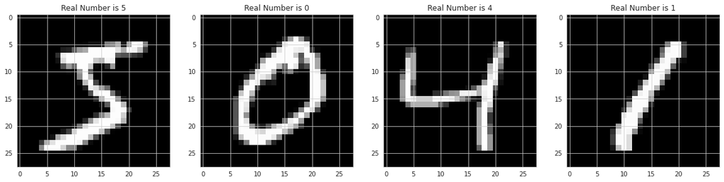

```python
# Load the dataset using MNIST dataset and get its description
# Plot mnist instances
# load (downloaded if needed) the MNIST dataset
(X_train, y_train), (X_test, y_test) = mnist.load_data()

# Successfully loaded note
print("Loaded successfully.")

# And what is the data about
# plot 4 images as gray scale to show examples

fig, axis = plt.subplots(1, 4, figsize=(20, 10))
for i, ax in enumerate(axis.flat): # Print each images
    ax.imshow(X_train[i], cmap='gray') # This shows the picture
    digit = y_train[i] # Declare variable digit
    ax.set(title = f"Real Number is {digit}"); # State at the top the digit in each images' real number

# show the plot
plt.show()
```

# Exploratory Data Analysis: MNIST dataset

```python
# Legitemately load the data
mnistD = mnist.load_data()

# Turn the data (supposedly np.array) to dataframe (more convenient to explore data easily)
mnistDf = pd.DataFrame(data=mnistD)

#Successfully loaded note
print("Loaded successfully.")

# Print the data
mnistDf
```

```
Loaded successfully.
```

|  | 0 | 1 |
| --- | --- | --- |
| 0 | [[[0, 0, 0, 0, 0, 0, 0, 0, 0, 0, 0, 0, 0, 0, 0... | [5, 0, 4, 1, 9, 2, 1, 3, 1, 4, 3, 5, 3, 6, 1, ... |
| 1 | [[[0, 0, 0, 0, 0, 0, 0, 0, 0, 0, 0, 0, 0, 0, 0... | [7, 2, 1, 0, 4, 1, 4, 9, 5, 9, 0, 6, 9, 0, 1, ... |

The values in [0, 0] would be the data in X_train, representing the image pixles  
The values in [0, 1] would be the data in y_train, representing the labels for data in X_train  
The values in [1, 0] would be the data in X_test, representing the image pixles  
The values in [1, 1] would be the data in y_test, representing the labels for data in X_test

```python
# print the shape of the training and test sets
print("X_train", X_train.shape)
print("y_train", y_train.shape)
print("X_test", X_test.shape)
print("y_test", y_test.shape)
```

```
X_train (60000, 28, 28)
y_train (60000,)
X_test (10000, 28, 28)
y_test (10000,)
```

```python
# Load the data
mnistD = mnist.load_data()

# Turn the data (supposedly np.array) to dataframe (more convenient to explore data easily)
mnistDf = pd.DataFrame(data=mnistD)

#Get the shape
print("Shape of mnistDf: ")
print(mnistDf.shape)
print()

#Get the information
print("summary of mnistDf: ")
mnistDf.info()
print()

#Get statistical summary
print("Statistical summary of mnistDf: ")
mnistDf.describe()
```

```
Shape of mnistDf:
(2, 2)

summary of mnistDf:
<class 'pandas.core.frame.DataFrame'>
RangeIndex: 2 entries, 0 to 1
Data columns (total 2 columns):
 #   Column  Non-Null Count  Dtype
---  ------  --------------  -----
 0   0       2 non-null      object
 1   1       2 non-null      object
dtypes: object(2)
memory usage: 160.0+ bytes

Statistical summary of mnistDf:
```

|  | 0 | 1 |
| --- | --- | --- |
| count | 2 | 2 |
| unique | 2 | 2 |
| top | [[[0, 0, 0, 0, 0, 0, 0, 0, 0, 0, 0, 0, 0, 0, 0... | [5, 0, 4, 1, 9, 2, 1, 3, 1, 4, 3, 5, 3, 6, 1, ... |
| freq | 1 | 1 |

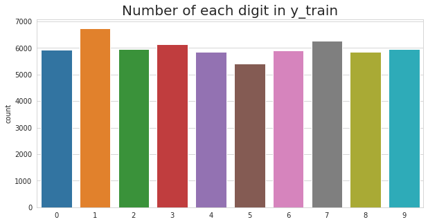

```python
# We can find out the count of each label(digit) in y_train
plt.figure(figsize=(10, 5))
sns.set_style("whitegrid")
sns.countplot(y_train).set_title("Number of each digit in y_train", fontsize=20)
plt.show()
```

Digit '1' has the highest count in y_train  
Digit '5' has the lowest count in y_train  
Nevertheless, all digits have generally similar count

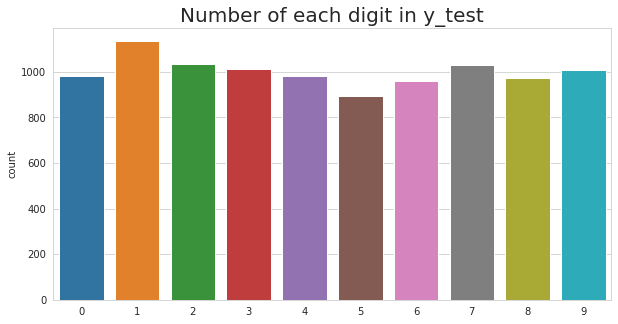

```python
# We can find out the count of each label(digit) in y_test
plt.figure(figsize=(10, 5))
sns.set_style("whitegrid")
sns.countplot(y_test).set_title("Number of each digit in y_test", fontsize=20)
plt.show()
```

Similar to y_train, digit '1' has the highest count in y_test. Digit '5' has the lowest count in y_test  
Nevertheless, all digits have generally similar count

#### Find out the digit in gray scale

- 0 - darkest
- 255 - lightest

This graph shows a 28 * 28 pixels with different values ranging from 0 - 255. In grayscale, 0 is black, 255 is white. When a digit is drawn, the pixel that was part of the digit will have a value different from the pixel that was part of the blank space. When the graph is shown, a contrast of colors shows a digit

```python
# Reshape to 3-dim
X_train_plot = X_train.reshape(-1, 28, 28)

# Function return digit in grayscale
def plot_digit(digit, dem = 28, font_size = 12):
    max_ax = font_size * dem                     # Set the maximum axis, to prevent grayscale digit block each other (too big)

    fig = plt.figure(figsize=(15, 15))           # Set the size
    plt.xlim([0, max_ax])                        # set x axis
    plt.ylim([0, max_ax])
    plt.axis('off')
    black = '#000000'

    for idx in range(dem):
        for jdx in range(dem):

            t = plt.text(idx * font_size, max_ax - jdx*font_size, digit[jdx][idx], fontsize = font_size, color = black)
            c = digit[jdx][idx] / 255.
            t.set_bbox(dict(facecolor=(c, c, c), alpha = 0.5, edgecolor = 'black'))

    plt.show()
```

```
The number shown in the graph below is  8
```

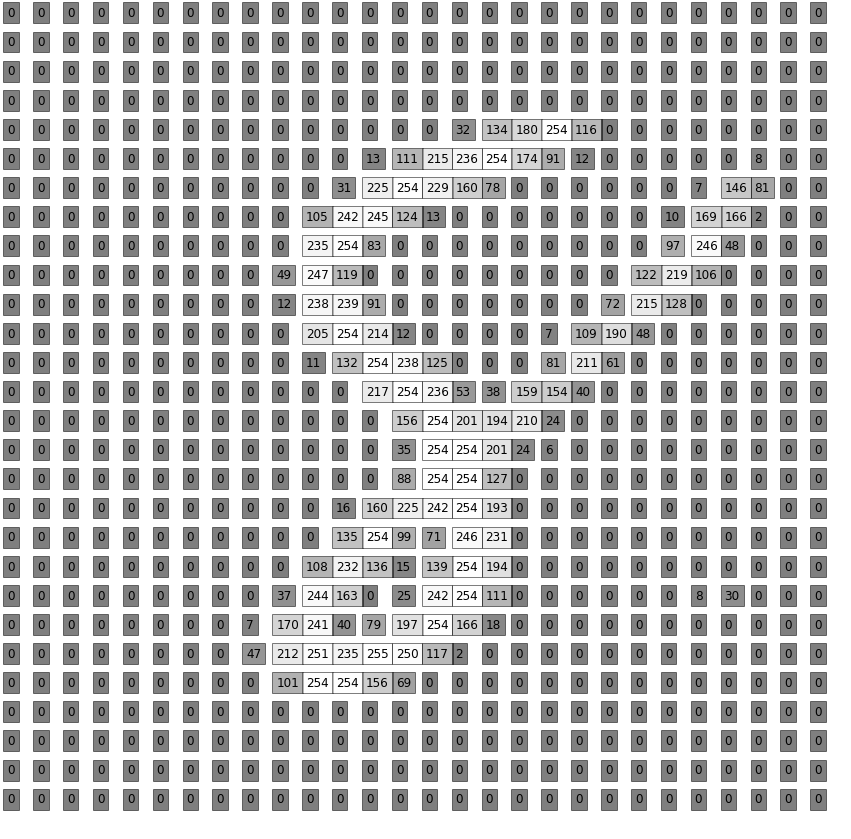

```python
# Print a random number instead of a fixed number: to see how different digits look like
rand_number = random.randint(0, len(y_train))
print("The number shown in the graph below is ",y_train[rand_number])
plot_digit(X_train_plot[rand_number])
```

## Data Cleaning/Feature Engineering

Check if it is needed to do data cleaning and feature engineering

```python
# Check the data if there are missing values
count = 0
for i in range(X_train.all()):
  if np.isnan(X_train) != False:
    count += 1

print("There are", count, "empty values")

# There shouldn't be duplicated records (no one would have the exact same handwriting... right?)
count = 0
for i in range(X_train.all()):
  if np.unique(X_train) == False:
    count += 1

print("There are", count, "duplicated values")
```

```
There are 0 empty values
There are 0 duplicated values
```

### Previous cell, we extract it for showing the data as images to know what is like as well as the exploratory data analysis.

### Now, we would load the dataset again to do the training.

Need to do a few steps (example code below):

- Normalization helps to reduce the effect of illumination's differences. CNN converge faster on 0-1 data than on 0-255.
- Reshape image in 4 dimensions (Number of images, height = 28px, width = 28px , canal = 1) For gray scale, canal = 1 This is easier to parse in data for data augmentation as well as in both LeNet-5 and AlexNet models.
- Encode labels to one hot vectors (e.g. 2 = [0,0,1,0,0,0,0,0,0,0])

```python
# fix random seed for reproducibility
seed = 88
np.random.seed(seed)

# load data
(X_train, y_train), (X_test, y_test) = mnist.load_data()

# Successfully loaded note
print("Loaded successfully.")

# normalize inputs from 0-255 to 0-1
X_train = X_train / 255
X_test = X_test / 255

# one hot encode outputs
y_train = np_utils.to_categorical(y_train)
y_test = np_utils.to_categorical(y_test)
num_classes = y_test.shape[1]

# To parse it in, will reshape the data to 4 dim
# Reshape data to 4 dim
X_train = X_train.reshape(X_train.shape[0], 28, 28, 1).astype('float32')
X_test = X_test.reshape(X_test.shape[0], 28, 28, 1).astype('float32')
```

```
Loaded successfully.
```

# Model building

### A simple MLP

MLP, parse in 3 dim and flatten image.

## Code below is the only change:

*flatten 28*28 images to a 784 vector for each image  
num_pixels = X_train.shape[1] *X_train.shape[2]*  
*X_train = X_train.reshape(X_train.shape[0], num_pixels).astype('float32')*  
*X_test = X_test.reshape(X_test.shape[0], num_pixels).astype('float32')*

```python
# fix random seed for reproducibility
seed = 88
np.random.seed(seed)
# load data
(X_train, y_train), (X_test, y_test) = mnist.load_data()

# Successfully loaded note
print("Loaded successfully.")

# flatten 28*28 images to a 784 vector for each image
num_pixels = X_train.shape[1] * X_train.shape[2]
X_train = X_train.reshape(X_train.shape[0], num_pixels).astype('float32')
X_test = X_test.reshape(X_test.shape[0], num_pixels).astype('float32')

# normalize inputs from 0-255 to 0-1
X_train = X_train / 255
X_test = X_test / 255

# one hot encode outputs
y_train = np_utils.to_categorical(y_train)
y_test = np_utils.to_categorical(y_test)
num_classes = y_test.shape[1]
```

```
Loaded successfully.
```

```python
# build the model
mlpSimmodel = Sequential()                                                                                 # create model
mlpSimmodel.add(Dense(num_pixels, input_dim=num_pixels, kernel_initializer='normal', activation='relu'))   # Fully Connected Layer
mlpSimmodel.add(Dense(num_classes, activation='softmax'))                                                  # Output Layer

# print the model summary
mlpSimmodel.summary()

# Compile model
mlpSimmodel.compile(loss='categorical_crossentropy', optimizer='adam', metrics=['accuracy'])

# Get time
start_time = time.time()

# Fit the model
history = mlpSimmodel.fit(X_train, y_train, validation_data=(X_test, y_test), epochs=10, batch_size=200, verbose=1)


# Final evaluation of the model: To get the percentage of the error
MLPStrains = mlpSimmodel.evaluate(X_train, y_train, verbose=0)                 # Scores for train set
MLPStests = mlpSimmodel.evaluate(X_test, y_test, verbose=0)                    # Scores for test set
MLPStrainl = 1-MLPStrains[-1]                                                  # Loss for train set
MLPStestl = 1-MLPStests[-1]                                                    # Loss for test set

print("------------- %s seconds -------------" % (time.time() - start_time))   # Get the run time
print("Training accuracy: %.2f%%" % (MLPStrains[-1]*100))
print("Baseline Error for train set: %.2f%%" % (MLPStrainl*100))
print("Test Accuracy: %.2f%%" % (MLPStests[-1]*100))
print("Baseline Error for test set: %.2f%%" % (MLPStestl*100))
```

```
Model: "sequential"
_________________________________________________________________
Layer (type)                 Output Shape              Param #
=================================================================
dense (Dense)                (None, 784)               615440
_________________________________________________________________
dense_1 (Dense)              (None, 10)                7850
=================================================================
Total params: 623,290
Trainable params: 623,290
Non-trainable params: 0
_________________________________________________________________
------------- 13.726576089859009 seconds -------------
Training accuracy: 99.93%
Baseline Error for train set: 0.07%
Test Accuracy: 98.23%
Baseline Error for test set: 1.77%
```

```python
# Get the y, number of epochs
lepochs = [e+1 for e in range(len(history.history['loss']))]
lepochs
```

```
[1, 2, 3, 4, 5, 6, 7, 8, 9, 10]
```

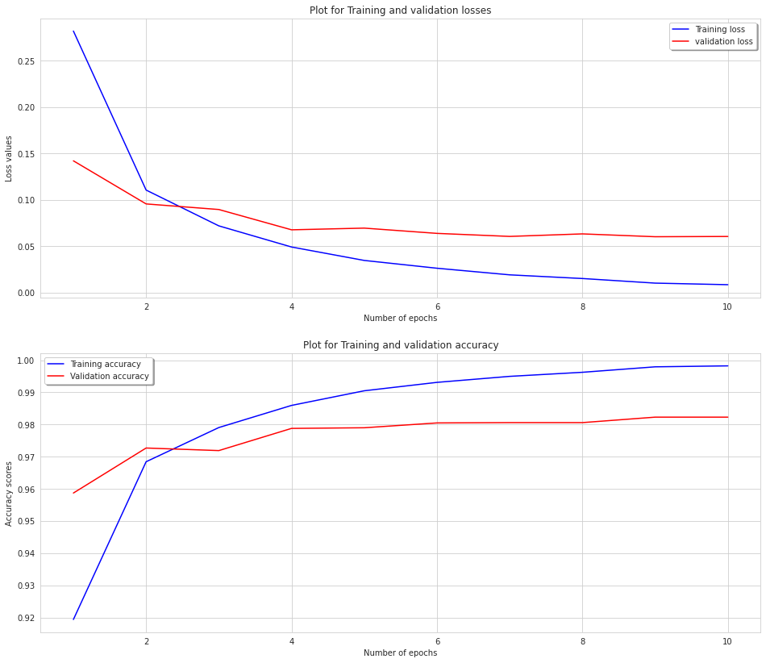

```python
# Plot the loss and accuracy curves for training and validation
fig, ax = plt.subplots(2,1, figsize=(16, 14))                                               # Setting the subplots and size
ax[0].plot(lepochs, history.history['loss'], color='b', label="Training loss")              # Plotting the Train loss
ax[0].plot(lepochs, history.history['val_loss'], color='r', label="validation loss")        # Plotting the test loss
ax[0].set_title("Plot for Training and validation losses")                                  # Set title
ax[0].set_ylabel('Loss values')                                                             # Set x label
ax[0].set_xlabel('Number of epochs')                                                        # Set y label
legend = ax[0].legend(loc='best', shadow=True)                                              # Place the legend at the best position when the graph is plotted

ax[1].plot(lepochs, history.history['accuracy'], color='b', label="Training accuracy")      # Plotting the Train accuracy
ax[1].plot(lepochs, history.history['val_accuracy'], color='r',label="Validation accuracy") # Plotting the Test accuracy
ax[1].set_title("Plot for Training and validation accuracy")                                # Set title
ax[1].set_ylabel('Accuracy scores')                                                         # Set x label
ax[1].set_xlabel('Number of epochs')                                                        # Set y label
legend = ax[1].legend(loc='best', shadow=True)                                              # Place the legend at the best position when the graph is plotted
plt.show()
```

### MLP confusion matrix

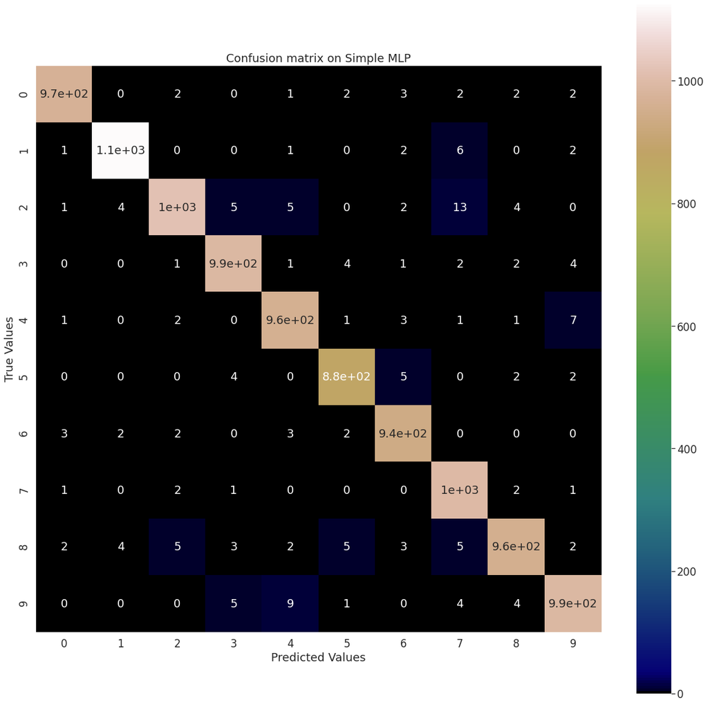

```python
plt.figure(figsize=(20, 20))                         # Set Figure
sns.set(font_scale=1.5)                              # Set the font size

y_pred = mlpSimmodel.predict(X_test)                 # Predict encoded label as 2 => [0, 0, 1, 0, 0, 0, 0, 0, 0, 0]

y_pred = np.argmax(y_pred, 1)                        # Decode Predicted labels
y_test = np.argmax(y_test, 1)                        # Decode labels

matrix = confusion_matrix(y_test, y_pred)            # Confusion matrix of correct labels against predicted labels

# Plot Confusion matrix
sns.heatmap(matrix.T, square=True, annot=True, cmap='gist_earth').set_title("Confusion matrix on Simple MLP")
plt.xlabel('Predicted Values')
plt.ylabel('True Values')
plt.show()
```

# Model building

### A simple CNN

- CONV (30 features 5*5)
- POOL (max 2*2)
- FC (128 neurons)
- Output layer (softmax 10 neurons)

```python
# fix random seed for reproducibility
seed = 88
np.random.seed(seed)

# load data
(X_train, y_train), (X_test, y_test) = mnist.load_data()

# Successfully loaded note
print("Loaded successfully.")

# normalize inputs from 0-255 to 0-1
X_train = X_train / 255
X_test = X_test / 255

# one hot encode outputs
y_train = np_utils.to_categorical(y_train)
y_test = np_utils.to_categorical(y_test)
num_classes = y_test.shape[1]

# To parse it in, will reshape the data to 4 dim
# Reshape data to 4 dim
X_train = X_train.reshape(X_train.shape[0], 28, 28, 1).astype('float32')
X_test = X_test.reshape(X_test.shape[0], 28, 28, 1).astype('float32')
```

```
Loaded successfully.
```

```python
# build the model
cnnmodel = Sequential()                                    # create model
cnnmodel.add(Conv2D(30, (5, 5), activation='relu'))        # 1st Convolutional Layer
cnnmodel.add(MaxPooling2D(pool_size=(2, 2)))               # Max Pooling
cnnmodel.add(Flatten())                                    # Fully Connected Layer
cnnmodel.add(Dense(128, activation='relu'))                # 1st Fully Connected Layer
cnnmodel.add(Dense(num_classes, activation='softmax'))     # Output Layer

# Compile model
cnnmodel.compile(loss='categorical_crossentropy', optimizer='adam', metrics=['accuracy'])

# Get time
start_time = time.time()

# Fit the model
history = cnnmodel.fit(X_train, y_train, validation_data=(X_test, y_test), epochs=10, batch_size=200, verbose=1)

# Print the model summary
cnnmodel.summary()

# Final evaluation of the model: To get the percentage of the error
cnntrains = cnnmodel.evaluate(X_train, y_train, verbose=0)                    # Scores for train set
cnntests = cnnmodel.evaluate(X_test, y_test, verbose=0)                       # Scores for test set
cnntrainl = 1-cnntrains[-1]                                                   # Loss for train set
cnntestl = 1-cnntests[-1]                                                     # Loss for test set

print("------------- %s seconds -------------" % (time.time() - start_time))  # Get the run time
print("Training accuracy: %.2f%%" % (cnntrains[-1]*100))
print("Baseline Error for train set: %.2f%%" % (cnntrainl*100))
print("Test Accuracy: %.2f%%" % (cnntests[-1]*100))
print("Baseline Error for test set: %.2f%%" % (cnntestl*100))
```

```
Model: "sequential_71"
_________________________________________________________________
Layer (type)                 Output Shape              Param #
=================================================================
conv2d_207 (Conv2D)          (200, 24, 24, 30)         780
_________________________________________________________________
max_pooling2d_105 (MaxPoolin (200, 12, 12, 30)         0
_________________________________________________________________
flatten_70 (Flatten)         (200, 4320)               0
_________________________________________________________________
dense_177 (Dense)            (200, 128)                553088
_________________________________________________________________
dense_178 (Dense)            (200, 10)                 1290
=================================================================
Total params: 555,158
Trainable params: 555,158
Non-trainable params: 0
_________________________________________________________________
------------- 15.668577671051025 seconds -------------
Training accuracy: 99.74%
Baseline Error for train set: 0.26%
Test Accuracy: 98.91%
Baseline Error for test set: 1.09%
```

```python
# Get the y, number of epochs
lepochs = [e+1 for e in range(len(history.history['loss']))]
lepochs
```

```
[1, 2, 3, 4, 5, 6, 7, 8, 9, 10]
```

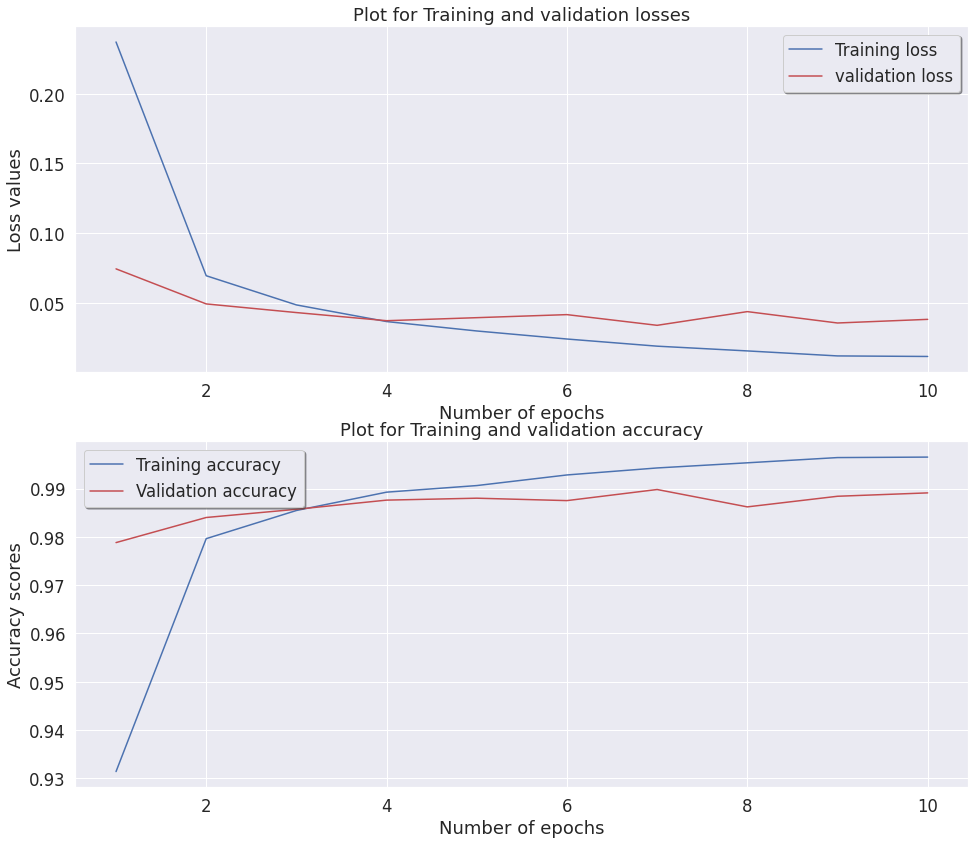

```python
# Plot the loss and accuracy curves for training and validation
fig, ax = plt.subplots(2,1, figsize=(16, 14))                                               # Setting the subplots and size
ax[0].plot(lepochs, history.history['loss'], color='b', label="Training loss")              # Plotting the Train loss
ax[0].plot(lepochs, history.history['val_loss'], color='r', label="validation loss")        # Plotting the test loss
ax[0].set_title("Plot for Training and validation losses")                                  # Set title
ax[0].set_ylabel('Loss values')                                                             # Set x label
ax[0].set_xlabel('Number of epochs')                                                        # Set y label
legend = ax[0].legend(loc='best', shadow=True)                                              # Place the legend at the best position when the graph is plotted

ax[1].plot(lepochs, history.history['accuracy'], color='b', label="Training accuracy")      # Plotting the Train accuracy
ax[1].plot(lepochs, history.history['val_accuracy'], color='r',label="Validation accuracy") # Plotting the Test accuracy
ax[1].set_title("Plot for Training and validation accuracy")                                # Set title
ax[1].set_ylabel('Accuracy scores')                                                         # Set x label
ax[1].set_xlabel('Number of epochs')                                                        # Set y label
legend = ax[1].legend(loc='best', shadow=True)                                              # Place the legend at the best position when the graph is plotted
plt.show()
```

### CNN confusion matrix

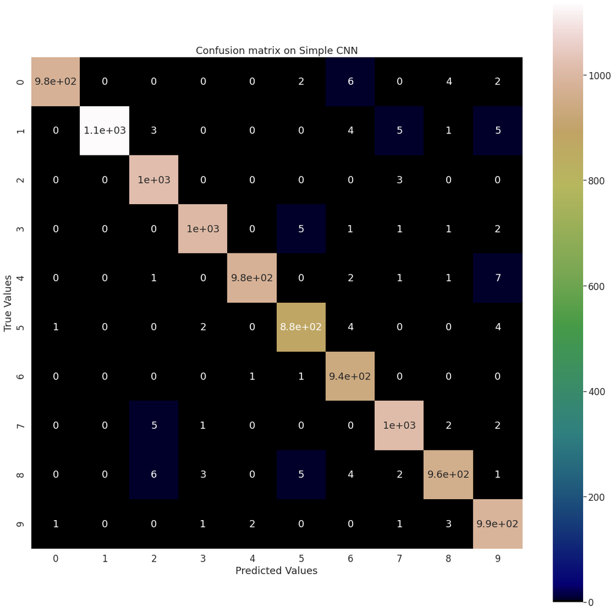

```python
plt.figure(figsize=(20, 20))                         # Set Figure
sns.set(font_scale=1.5)                              # Set the font size

y_pred = cnnmodel.predict(X_test)                    # Predict encoded label as 2 => [0, 0, 1, 0, 0, 0, 0, 0, 0, 0]

y_pred = np.argmax(y_pred, 1)                        # Decode Predicted labels
y_test = np.argmax(y_test, 1)                        # Decode labels

matrix = confusion_matrix(y_test, y_pred)            # Confusion matrix of correct labels against predicted labels

# Plot Confusion matrix
sns.heatmap(matrix.T, square=True, annot=True, cmap='gist_earth').set_title("Confusion matrix on Simple CNN")
plt.xlabel('Predicted Values')
plt.ylabel('True Values')
plt.show()
```

# Model building

### CNN: LeNet-5

```python
# fix random seed for reproducibility
seed = 88
np.random.seed(seed)

# load data
(X_train, y_train), (X_test, y_test) = mnist.load_data()

# Successfully loaded note
print("Loaded successfully.")

# normalize inputs from 0-255 to 0-1
X_train = X_train / 255
X_test = X_test / 255

# one hot encode outputs
y_train = np_utils.to_categorical(y_train)
y_test = np_utils.to_categorical(y_test)
num_classes = y_test.shape[1]

# To parse it in, will reshape the data to 4 dim
# Reshape data to 4 dim
X_train = X_train.reshape(X_train.shape[0], 28, 28, 1).astype('float32')
X_test = X_test.reshape(X_test.shape[0], 28, 28, 1).astype('float32')
```

```
Loaded successfully.
```

```python
# build the model
Lemodel = Sequential()                                                  # create model
Lemodel.add(Conv2D(filters=6, kernel_size=(3, 3), activation='relu'))   # 1st Convolutional layer
Lemodel.add(AveragePooling2D())                                         # Avg Pooling
Lemodel.add(Conv2D(filters=16, kernel_size=(3, 3), activation='relu'))  # 2nd Convolutional layer
Lemodel.add(AveragePooling2D())                                         # Avg Pooling
Lemodel.add(Flatten())                                                  # Fully connected layer
Lemodel.add(Dense(120, activation='relu'))                              # 1st Fully connected layer
Lemodel.add(Dense(84, activation='relu'))                               # 2nd Fully connected layer
Lemodel.add(Dense(num_classes, activation = 'softmax'))                 # Output layer


# Compile model
Lemodel.compile(loss='categorical_crossentropy', optimizer='adam', metrics=['accuracy'])

epochs = 20

# Fit the model
history = Lemodel.fit(X_train, y_train, validation_data=(X_test, y_test), epochs=epochs, batch_size=200, verbose=1)

# Print the model summary
Lemodel.summary()


# Final evaluation of the model: To get the percentage of the error
LNtrains = Lemodel.evaluate(X_train, y_train, verbose=0)                     # Scores for train set
LNtests = Lemodel.evaluate(X_test, y_test, verbose=0)                        # Scores for test set
LNtrainl = 1-LNtrains[-1]                                                    # Loss for train set
LNtestl = 1-LNtests[-1]                                                      # Loss for test set
print("Training accuracy: %.2f%%" % (LNtrains[-1]*100))
print("Baseline Error for train set: %.2f%%" % (LNtrainl*100))
print("Test Accuracy: %.2f%%" % (LNtests[-1]*100))
print("Baseline Error for test set: %.2f%%" % (LNtestl*100))
```

```
Model: "sequential_2"
_________________________________________________________________
Layer (type)                 Output Shape              Param #
=================================================================
conv2d_2 (Conv2D)            (200, 26, 26, 6)          60
_________________________________________________________________
average_pooling2d (AveragePo (200, 13, 13, 6)          0
_________________________________________________________________
conv2d_3 (Conv2D)            (200, 11, 11, 16)         880
_________________________________________________________________
average_pooling2d_1 (Average (200, 5, 5, 16)           0
_________________________________________________________________
flatten_1 (Flatten)          (200, 400)                0
_________________________________________________________________
dense_5 (Dense)              (200, 120)                48120
_________________________________________________________________
dense_6 (Dense)              (200, 84)                 10164
_________________________________________________________________
dense_7 (Dense)              (200, 10)                 850
=================================================================
Total params: 60,074
Trainable params: 60,074
Non-trainable params: 0
_________________________________________________________________
Training accuracy: 99.74%
Baseline Error for train set: 0.26%
Test Accuracy: 99.02%
Baseline Error for test set: 0.98%
```

```python
# Get the y, number of epochs
lepochs = [e+1 for e in range(len(history.history['loss']))]
lepochs
```

```
[1, 2, 3, 4, 5, 6, 7, 8, 9, 10, 11, 12, 13, 14, 15, 16, 17, 18, 19, 20]
```

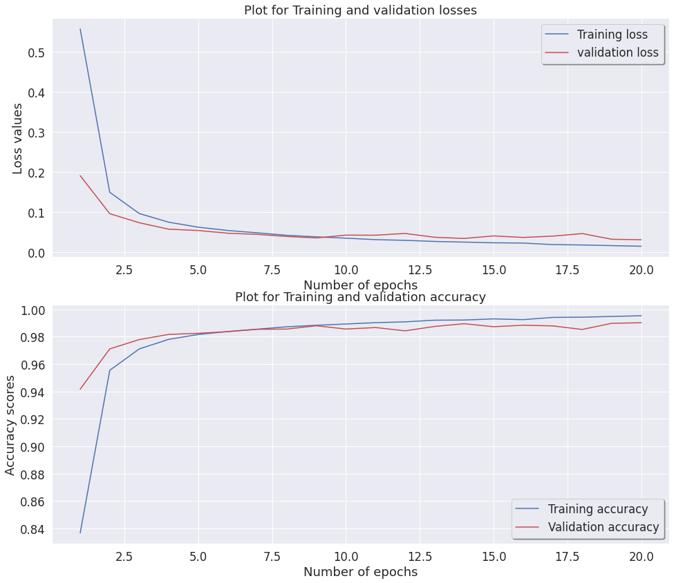

```python
# Plot the loss and accuracy curves for training and validation
fig, ax = plt.subplots(2,1, figsize=(16, 14))                                               # Setting the subplots and size
ax[0].plot(lepochs, history.history['loss'], color='b', label="Training loss")              # Plotting the Train loss
ax[0].plot(lepochs, history.history['val_loss'], color='r', label="validation loss")        # Plotting the test loss
ax[0].set_title("Plot for Training and validation losses")                                  # Set title
ax[0].set_ylabel('Loss values')                                                             # Set x label
ax[0].set_xlabel('Number of epochs')                                                        # Set y label
legend = ax[0].legend(loc='best', shadow=True)                                              # Place the legend at the best position when the graph is plotted

ax[1].plot(lepochs, history.history['accuracy'], color='b', label="Training accuracy")      # Plotting the Train accuracy
ax[1].plot(lepochs, history.history['val_accuracy'], color='r',label="Validation accuracy") # Plotting the Test accuracy
ax[1].set_title("Plot for Training and validation accuracy")                                # Set title
ax[1].set_ylabel('Accuracy scores')                                                         # Set x label
ax[1].set_xlabel('Number of epochs')                                                        # Set y label
legend = ax[1].legend(loc='best', shadow=True)                                              # Place the legend at the best position when the graph is plotted
plt.show()
```

### CNN: LeNet-5 with data augmentation.

```python
# Data Augmenting: prevent overfitting
datagen = ImageDataGenerator(
        featurewise_center=False,              # set input mean to 0 over the dataset
        samplewise_center=False,               # set each sample mean to 0
        featurewise_std_normalization=False,   # divide inputs by std of the dataset
        samplewise_std_normalization=False,    # divide each input by its std
        zca_whitening=False,                   # apply ZCA whitening
        rotation_range=10,                     # randomly rotate images in the range (degrees, 0 to 180)
        zoom_range = 0.1,                      # Randomly zoom image
        width_shift_range=0.1,                 # randomly shift images horizontally (fraction of total width)
        height_shift_range=0.1,                # randomly shift images vertically (fraction of total height)
        horizontal_flip=False,                 # randomly flip images
        vertical_flip=False)                   # randomly flip images

datagen.fit(X_train)


# build the model
LeDamodel = Sequential()                                                   # create model
LeDamodel.add(Conv2D(filters=6, kernel_size=(3, 3), activation='relu'))    # 1st Convolutional Layer
LeDamodel.add(AveragePooling2D())                                          # Avg Pooling
LeDamodel.add(Conv2D(filters=16, kernel_size=(3, 3), activation='relu'))   # 2nd Convolutional layer
LeDamodel.add(AveragePooling2D())                                          # Avg Pooling
LeDamodel.add(Flatten())                                                   # Fully Connected Layer
LeDamodel.add(Dense(120, activation='relu'))                               # 1st Fully Connected Layer
LeDamodel.add(Dense(84, activation='relu'))                                # 2nd Fully Connected Layer
LeDamodel.add(Dense(num_classes, activation = 'softmax'))                  # Output Layer


# Compile model
LeDamodel.compile(loss='categorical_crossentropy', optimizer='adam', metrics=['accuracy'])

epochs = 20

# Fit the model
history = LeDamodel.fit(datagen.flow(X_train, y_train, batch_size = 200), validation_data=(X_test, y_test), epochs = epochs, verbose=1)

# Print the model summary
LeDamodel.summary()


# Final evaluation of the model
# This is to get the percentage of the error
DLNtrains = LeDamodel.evaluate(X_train, y_train, verbose=0)     # Scores for train set
DLNtests = LeDamodel.evaluate(X_test, y_test, verbose=0)        # Scores for test set
DLNtrainl = 1-DLNtrains[-1]                                     # Loss for train set
DLNtestl = 1-DLNtests[-1]                                       # Loss for test set
print("Training accuracy: %.2f%%" % (DLNtrains[-1]*100))
print("Baseline Error for train set: %.2f%%" % (DLNtrainl*100))
print("Test Accuracy: %.2f%%" % (DLNtests[-1]*100))
print("Baseline Error for test set: %.2f%%" % (DLNtestl*100))
```

```
Model: "sequential_3"
_________________________________________________________________
Layer (type)                 Output Shape              Param #
=================================================================
conv2d_4 (Conv2D)            (None, None, None, 6)     60
_________________________________________________________________
average_pooling2d_2 (Average (None, None, None, 6)     0
_________________________________________________________________
conv2d_5 (Conv2D)            (None, None, None, 16)    880
_________________________________________________________________
average_pooling2d_3 (Average (None, None, None, 16)    0
_________________________________________________________________
flatten_2 (Flatten)          (None, None)              0
_________________________________________________________________
dense_8 (Dense)              (None, 120)               48120
_________________________________________________________________
dense_9 (Dense)              (None, 84)                10164
_________________________________________________________________
dense_10 (Dense)             (None, 10)                850
=================================================================
Total params: 60,074
Trainable params: 60,074
Non-trainable params: 0
_________________________________________________________________
Training accuracy: 99.27%
Baseline Error for train set: 0.73%
Test Accuracy: 99.18%
Baseline Error for test set: 0.82%
```

```python
# Get the y, number of epochs
lepochs = [e+1 for e in range(len(history.history['loss']))]
lepochs
```

```
[1, 2, 3, 4, 5, 6, 7, 8, 9, 10, 11, 12, 13, 14, 15, 16, 17, 18, 19, 20]
```

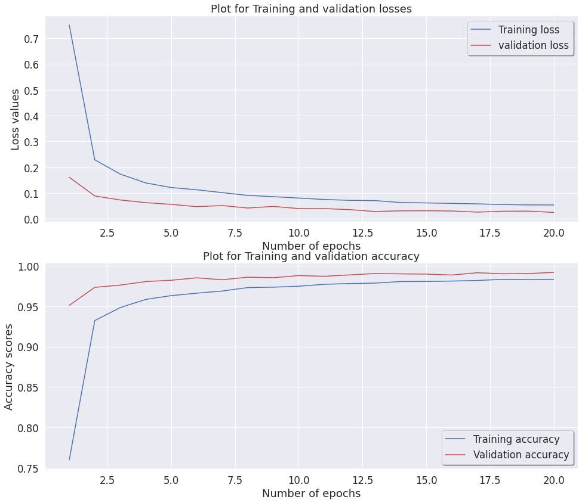

```python
# Plot the loss and accuracy curves for training and validation
fig, ax = plt.subplots(2,1, figsize=(16, 14))                                               # Setting the subplots and size
ax[0].plot(lepochs, history.history['loss'], color='b', label="Training loss")              # Plotting the Train loss
ax[0].plot(lepochs, history.history['val_loss'], color='r', label="validation loss")        # Plotting the test loss
ax[0].set_title("Plot for Training and validation losses")                                  # Set title
ax[0].set_ylabel('Loss values')                                                             # Set x label
ax[0].set_xlabel('Number of epochs')                                                        # Set y label
legend = ax[0].legend(loc='best', shadow=True)                                              # Place the legend at the best position when the graph is plotted

ax[1].plot(lepochs, history.history['accuracy'], color='b', label="Training accuracy")      # Plotting the Train accuracy
ax[1].plot(lepochs, history.history['val_accuracy'], color='r',label="Validation accuracy") # Plotting the Test accuracy
ax[1].set_title("Plot for Training and validation accuracy")                                # Set title
ax[1].set_ylabel('Accuracy scores')                                                         # Set x label
ax[1].set_xlabel('Number of epochs')                                                        # Set y label
legend = ax[1].legend(loc='best', shadow=True)                                              # Place the legend at the best position when the graph is plotted
plt.show()
```

### CNN: LeNet-5 tuning hyperparameter with random search.

```python
# Creates a model given an activation and learning rate
def create_model(learning_rate, activation):

  opt = keras.optimizers.Adam(lr = learning_rate)                           # Create an Adam optimizer with the given learning rate

  LeDaRmodel = Sequential()                                                 # create model
  LeDaRmodel.add(Conv2D(filters=6, kernel_size=(3, 3), activation='relu'))  # 1st Convolutional Layer
  LeDaRmodel.add(AveragePooling2D())                                        # Avg Pooling
  LeDaRmodel.add(Conv2D(filters=16, kernel_size=(3, 3), activation='relu')) # 2nd Convolutional Layer
  LeDaRmodel.add(AveragePooling2D())                                        # Avg Pooling
  LeDaRmodel.add(Flatten())                                                 # Fully Connected Layer
  LeDaRmodel.add(Dense(120, activation='relu'))                             # 1st Fully Connected Layer
  LeDaRmodel.add(Dense(84, activation='relu'))                              # 2nd Fully Connected Layer
  LeDaRmodel.add(Dense(num_classes, activation = 'softmax'))                # Output Layer

  # Compile your model with your optimizer, loss, and metrics
  LeDaRmodel.compile(optimizer = opt, loss = 'categorical_crossentropy', metrics = ['accuracy'])
  return LeDaRmodel


# Create a KerasClassifier
LeDaRmodel = KerasClassifier(build_fn = create_model)

# Define the parameters to try out
params = {'activation': ['relu', 'tahn'], 'batch_size': [150, 200, 250], 'epochs': [20, 30], 'learning_rate': [0.1, 0.01]}

# Create a randomize search cv object passing in the parameters to try
random_search = RandomizedSearchCV(LeDaRmodel, param_distributions = params, cv = 3)

# Get time
start_time = time.time()

# Running random_search.fit(X,y) would start the search,but it takes too long!
rand = random_search.fit(X_train, y_train)
```

```python
# Print results
print("Best: %f using %s" % (rand.best_score_, rand.best_params_))
randParam = rand.best_params_
```

```
Best: 0.985483 using {'learning_rate': 0.01, 'epochs': 20, 'batch_size': 200, 'activation': 'tahn'}
```

```python
# Data Augmenting: prevent overfitting
datagen = ImageDataGenerator(
        featurewise_center=False,              # set input mean to 0 over the dataset
        samplewise_center=False,               # set each  sample mean to 0
        featurewise_std_normalization=False,   # divide inputs by std of the dataset
        samplewise_std_normalization=False,    # divide each input by its std
        zca_whitening=False,                   # apply ZCA whitening
        rotation_range=10,                     # randomly rotate images in the range (degrees, 0 to 180)
        zoom_range = 0.1,                      # Randomly zoom image
        width_shift_range=0.1,                 # randomly shift images horizontally (fraction of total width)
        height_shift_range=0.1,                # randomly shift images vertically (fraction of total height)
        horizontal_flip=False,                 # randomly flip images
        vertical_flip=False)                   # randomly flip images

datagen.fit(X_train)

# Bring in the callbacks
early_stop = EarlyStopping(monitor='val_loss', min_delta=0, patience=10, mode='auto')

LeDaRmodel = Sequential()                                                 # create model
LeDaRmodel.add(Conv2D(filters=6, kernel_size=(3, 3), activation='relu'))  # 1st Convolutional Layer
LeDaRmodel.add(AveragePooling2D())                                        # Avg Pooling
LeDaRmodel.add(Conv2D(filters=16, kernel_size=(3, 3), activation='relu')) # 2nd Convolutional Layer
LeDaRmodel.add(AveragePooling2D())                                        # Avg Pooling
LeDaRmodel.add(Flatten())                                                 # Fully Connected layer
LeDaRmodel.add(Dense(120, activation='relu'))                             # 1st Fully Connected layer
LeDaRmodel.add(Dense(84, activation='relu'))                              # 2nd Fully Connected layer
LeDaRmodel.add(Dense(num_classes, activation = 'softmax'))                # Output layer


# set learning rate from the best params
opt = keras.optimizers.Adam(learning_rate=randParam.get('learning_rate'))

# Compile model
LeDaRmodel.compile(loss='categorical_crossentropy', optimizer='adam', metrics=['accuracy'])


epochs = randParam.get('epochs')

# Fit the model
history = LeDaRmodel.fit(datagen.flow(X_train, y_train, batch_size = randParam.get('batch_size')), validation_data=(X_test, y_test), epochs = epochs, verbose=1, callbacks=early_stop)

# print the model summary
LeDaRmodel.summary()


# Final evaluation of the model: To get the percentage of the error
ALNtrains = LeDaRmodel.evaluate(X_train, y_train, verbose=0)                  # Scores for train set
ALNtests = LeDaRmodel.evaluate(X_test, y_test, verbose=0)                     # Scores for test set
ALNtrainl = 1-ALNtrains[-1]                                                   # Loss for train set
ALNtestl = 1-ALNtests[-1]                                                     # Loss for test set

print("------------- %s seconds -------------" % (time.time() - start_time))  # Get the run time
print("Training accuracy: %.2f%%" % (ALNtrains[-1]*100))
print("Baseline Error for train set: %.2f%%" % (ALNtrainl*100))
print("Test Accuracy: %.2f%%" % (ALNtests[-1]*100))
print("Baseline Error for test set: %.2f%%" % (ALNtestl*100))
```

```
Model: "sequential_35"
_________________________________________________________________
Layer (type)                 Output Shape              Param #
=================================================================
conv2d_68 (Conv2D)           (None, None, None, 6)     60
_________________________________________________________________
average_pooling2d_66 (Averag (None, None, None, 6)     0
_________________________________________________________________
conv2d_69 (Conv2D)           (None, None, None, 16)    880
_________________________________________________________________
average_pooling2d_67 (Averag (None, None, None, 16)    0
_________________________________________________________________
flatten_34 (Flatten)         (None, None)              0
_________________________________________________________________
dense_104 (Dense)            (None, 120)               48120
_________________________________________________________________
dense_105 (Dense)            (None, 84)                10164
_________________________________________________________________
dense_106 (Dense)            (None, 10)                850
=================================================================
Total params: 60,074
Trainable params: 60,074
Non-trainable params: 0
_________________________________________________________________
------------- 886.9849810600281 seconds -------------
Training accuracy: 98.98%
Baseline Error for train set: 1.02%
Test Accuracy: 98.83%
Baseline Error for test set: 1.17%
```

```python
# Get the y, number of epochs
lepochs = [e+1 for e in range(len(history.history['loss']))]
lepochs
```

```
[1, 2, 3, 4, 5, 6, 7, 8, 9, 10, 11, 12, 13, 14, 15, 16, 17, 18, 19, 20]
```

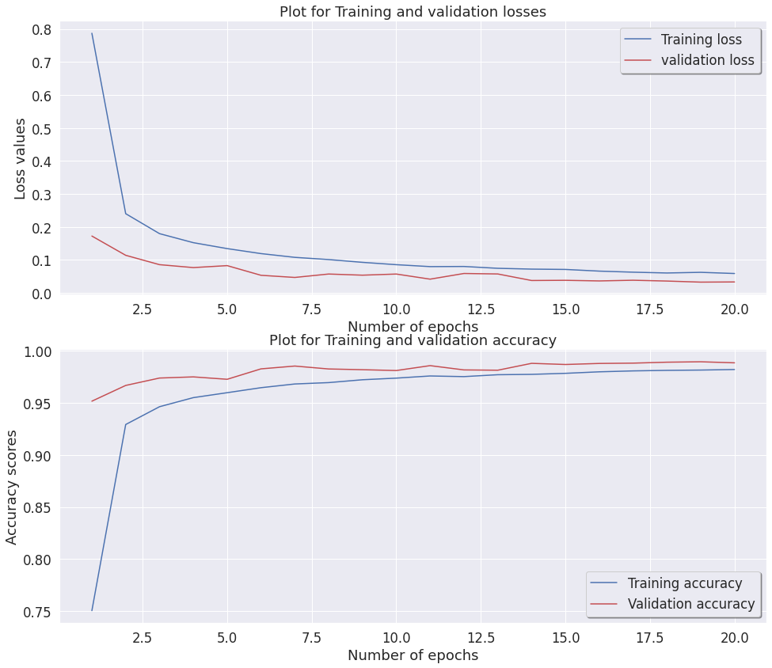

```python
# Plot the loss and accuracy curves for training and validation
fig, ax = plt.subplots(2,1, figsize=(16, 14))                                               # Setting the subplots and size
ax[0].plot(lepochs, history.history['loss'], color='b', label="Training loss")              # Plotting the Train loss
ax[0].plot(lepochs, history.history['val_loss'], color='r', label="validation loss")        # Plotting the test loss
ax[0].set_title("Plot for Training and validation losses")                                  # Set title
ax[0].set_ylabel('Loss values')                                                             # Set x label
ax[0].set_xlabel('Number of epochs')                                                        # Set y label
legend = ax[0].legend(loc='best', shadow=True)                                              # Place the legend at the best position when the graph is plotted

ax[1].plot(lepochs, history.history['accuracy'], color='b', label="Training accuracy")      # Plotting the Train accuracy
ax[1].plot(lepochs, history.history['val_accuracy'], color='r',label="Validation accuracy") # Plotting the Test accuracy
ax[1].set_title("Plot for Training and validation accuracy")                                # Set title
ax[1].set_ylabel('Accuracy scores')                                                         # Set x label
ax[1].set_xlabel('Number of epochs')                                                        # Set y label
legend = ax[1].legend(loc='best', shadow=True)                                              # Place the legend at the best position when the graph is plotted
plt.show()
```

### CNN: LeNet-5 confusion matrix for the fine tuned LeNet-5

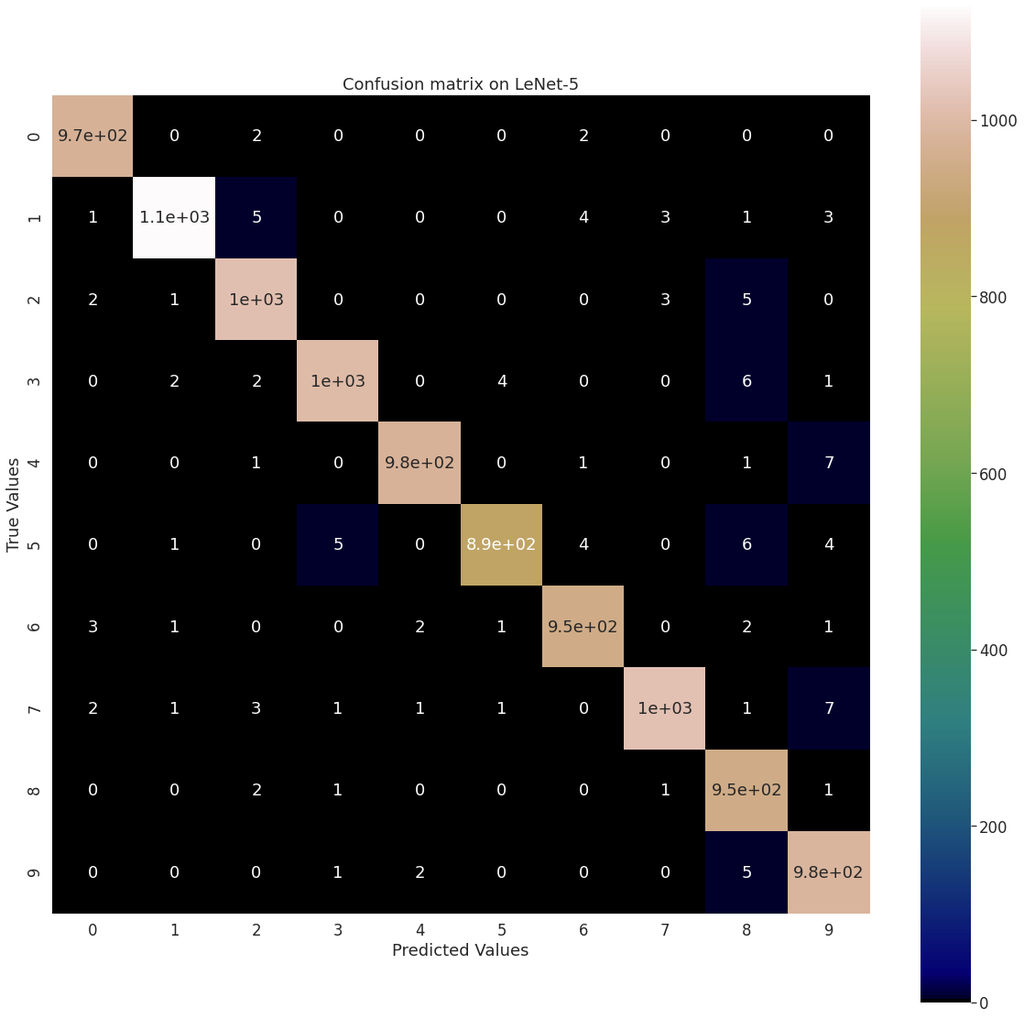

```python
plt.figure(figsize=(20, 20))                         # Set Figure
sns.set(font_scale=1.5)                              # Set the font size

Ly_pred = LeDaRmodel.predict(X_test)                 # Predict encoded label as 2 => [0, 0, 1, 0, 0, 0, 0, 0, 0, 0]

Ly_pred = np.argmax(Ly_pred, 1)                      # Decode Predicted labels
y_test = np.argmax(y_test, 1)                        # Decode labels

matrix = confusion_matrix(y_test, Ly_pred)           # Confusion matrix of correct labels against predicted labels

# Plot Confusion matrix
sns.heatmap(matrix.T, square=True, annot=True, cmap='gist_earth').set_title("Confusion matrix on LeNet-5")
plt.xlabel('Predicted Values')
plt.ylabel('True Values')
plt.show()
```

- Majority of the digits are classified correctly.
- However there are some digits were classified wrongly. LeNet-5 misclassify '7' as '9' as well as '4' as '9' the most as 7 of them were misclassified.
- Probably, the structures of '7' and '9' are similar. Direction of the writing is pointing downwards, top part of '7' might be curved which could cause '7' to look like '9' which makes the model to misclassify them.
- Likewise for '4' and '9'. Both have holes at the top part and some people might write a more cursive '4' which could look like '9'

# Model building

### CNN: AlexNet

- CONV (96 features maps + 11*11 + stride 4)
- POOL (max 3*3 patches + stride 2)
- CONV (256 feature maps + 5*5 + pad 2)
- POOL (max 3*3 patches + stride 2)
- CONV (384 feature maps + 3*3 + pad 1)
- CONV (384 feature maps + 3*3 + pad 1)
- CONV (384 feature maps + 3*3 + pad 1)
- POOL (max 3*3 patches + stride 2)
- FC (4096 neurons)
- FC (4096 neurons)
- Output layer (softmax 1000 neurons)

To parse it in, will reshape the data to 4 dim

```python
# fix random seed for reproducibility
seed = 88
np.random.seed(seed)

# load data
(X_train, y_train), (X_test, y_test) = mnist.load_data()

# Successfully loaded note
print("Loaded successfully.")

# normalize inputs from 0-255 to 0-1
X_train = X_train / 255
X_test = X_test / 255

# one hot encode outputs
y_train = np_utils.to_categorical(y_train)
y_test = np_utils.to_categorical(y_test)
num_classes = y_test.shape[1]

# To parse it in, will reshape the data to 4 dim
# Reshape data to 4 dim
X_train = X_train.reshape(X_train.shape[0], 28, 28, 1).astype('float32')
X_test = X_test.reshape(X_test.shape[0], 28, 28, 1).astype('float32')
```

```
Loaded successfully.
```

```python
Alexmodel = Sequential()                                                                                       # Create model
Alexmodel.add(Conv2D(filters=32, kernel_size=(3, 3), strides=(1, 1), padding='valid', activation='relu'))      # 1st Convolutional Layer
Alexmodel.add(MaxPooling2D(pool_size=(3, 3), strides=(1, 1), padding='valid'))                                 # Max Pooling
Alexmodel.add(Conv2D(filters=32, kernel_size=(3, 3), strides=(1, 1), padding='valid', activation='relu'))      # 2nd Convolutional Layer
Alexmodel.add(MaxPooling2D(pool_size=(3, 3), strides=(1, 1), padding='valid'))                                 # Max Pooling
Alexmodel.add(Conv2D(filters=64, kernel_size=(3, 3), strides=(1, 1), padding='valid', activation='relu'))      # 3rd Convolutional Layer
Alexmodel.add(Conv2D(filters=64, kernel_size=(3, 3), strides=(1, 1), padding='valid', activation='relu'))      # 4th Convolutional Layer
Alexmodel.add(MaxPooling2D(pool_size=(3, 3), strides=(2, 2), padding='valid'))                                 # Max Pooling
Alexmodel.add(Flatten())                                                                                       # Fully Connected layer
Alexmodel.add(Dense(512, activation='relu'))                                                                   # 1st Fully Connected Layer
Alexmodel.add(Dense(10, activation='softmax'))                                                                 # Output Layer: 10 classes so 10 neurons


# Compile the model
Alexmodel.compile(loss='categorical_crossentropy', optimizer='adam', metrics=['accuracy'])

epochs = 20

# Fit the model
history = Alexmodel.fit(X_train, y_train, validation_data=(X_test, y_test), epochs=epochs, batch_size=200, verbose=1)

# Print the model summary
Alexmodel.summary()


# Final evaluation of the model: To get the percentage of the error
ANtrains = Alexmodel.evaluate(X_train, y_train, verbose=0) # Scores for train set
ANtests = Alexmodel.evaluate(X_test, y_test, verbose=0)    # Scores for test set
ANtrainl = 1-ANtrains[-1]                                  # Loss for train set
ANtestl = 1-ANtests[-1]                                    # Loss for test set
print("Training accuracy: %.2f%%" % (ANtrains[-1]*100))
print("Baseline Error for train set: %.2f%%" % (ANtrainl*100))
print("Test Accuracy: %.2f%%" % (ANtests[-1]*100))
print("Baseline Error for test set: %.2f%%" % (ANtestl*100))
```

```
Model: "sequential_36"
_________________________________________________________________
Layer (type)                 Output Shape              Param #
=================================================================
conv2d_70 (Conv2D)           (200, 26, 26, 32)         320
_________________________________________________________________
max_pooling2d_2 (MaxPooling2 (200, 24, 24, 32)         0
_________________________________________________________________
conv2d_71 (Conv2D)           (200, 22, 22, 32)         9248
_________________________________________________________________
max_pooling2d_3 (MaxPooling2 (200, 20, 20, 32)         0
_________________________________________________________________
conv2d_72 (Conv2D)           (200, 18, 18, 64)         18496
_________________________________________________________________
conv2d_73 (Conv2D)           (200, 16, 16, 64)         36928
_________________________________________________________________
max_pooling2d_4 (MaxPooling2 (200, 7, 7, 64)           0
_________________________________________________________________
flatten_35 (Flatten)         (200, 3136)               0
_________________________________________________________________
dense_107 (Dense)            (200, 512)                1606144
_________________________________________________________________
dense_108 (Dense)            (200, 10)                 5130
=================================================================
Total params: 1,676,266
Trainable params: 1,676,266
Non-trainable params: 0
_________________________________________________________________
Training accuracy: 99.85%
Baseline Error for train set: 0.15%
Test Accuracy: 99.16%
Baseline Error for test set: 0.84%
```

```python
# Get the y, number of epochs
lepochs = [e+1 for e in range(len(history.history['loss']))]
lepochs
```

```
[1, 2, 3, 4, 5, 6, 7, 8, 9, 10, 11, 12, 13, 14, 15, 16, 17, 18, 19, 20]
```

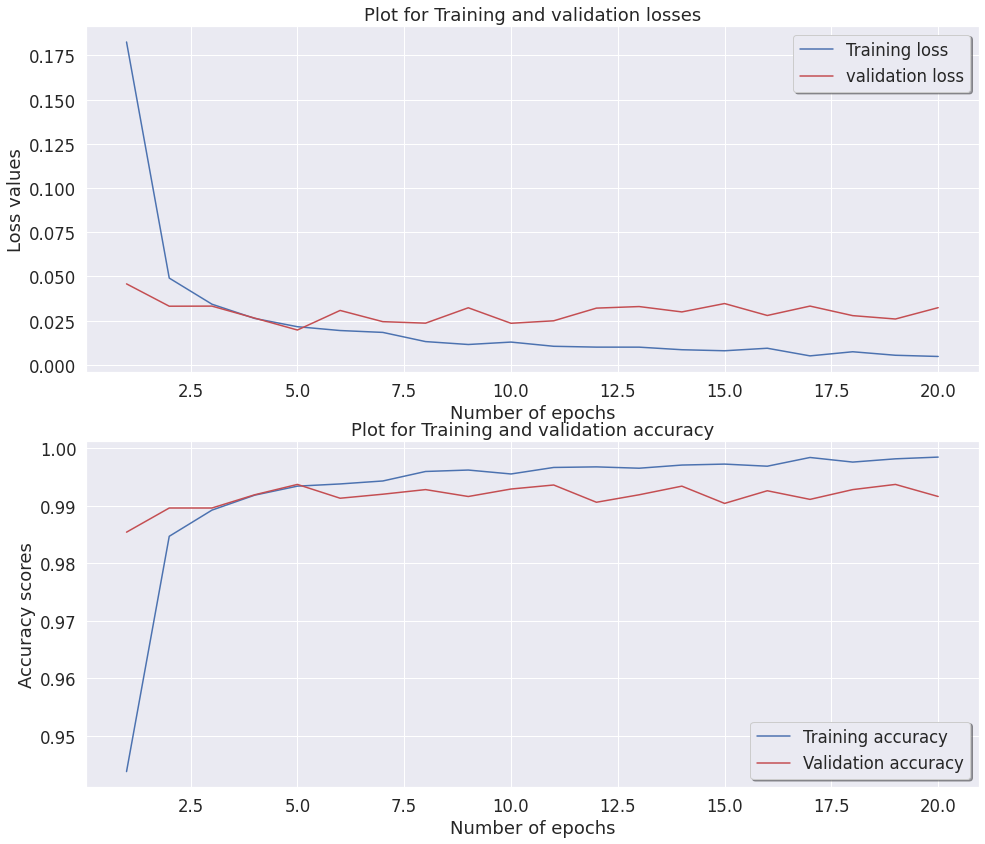

```python
# Plot the loss and accuracy curves for training and validation
fig, ax = plt.subplots(2,1, figsize=(16, 14))                                               # Setting the subplots and size
ax[0].plot(lepochs, history.history['loss'], color='b', label="Training loss")              # Plotting the Train loss
ax[0].plot(lepochs, history.history['val_loss'], color='r', label="validation loss")        # Plotting the test loss
ax[0].set_title("Plot for Training and validation losses")                                  # Set title
ax[0].set_ylabel('Loss values')                                                             # Set x label
ax[0].set_xlabel('Number of epochs')                                                        # Set y label
legend = ax[0].legend(loc='best', shadow=True)                                              # Place the legend at the best position when the graph is plotted

ax[1].plot(lepochs, history.history['accuracy'], color='b', label="Training accuracy")      # Plotting the Train accuracy
ax[1].plot(lepochs, history.history['val_accuracy'], color='r',label="Validation accuracy") # Plotting the Test accuracy
ax[1].set_title("Plot for Training and validation accuracy")                                # Set title
ax[1].set_ylabel('Accuracy scores')                                                         # Set x label
ax[1].set_xlabel('Number of epochs')                                                        # Set y label
legend = ax[1].legend(loc='best', shadow=True)                                              # Place the legend at the best position when the graph is plotted
plt.show()
```

### CNN: AlexNet with data augmentation.

```python
# Data Augmenting: prevent overfitting
datagen = ImageDataGenerator(
        featurewise_center=False,             # set input mean to 0 over the dataset
        samplewise_center=False,              # set each sample mean to 0
        featurewise_std_normalization=False,  # divide inputs by std of the dataset
        samplewise_std_normalization=False,   # divide each input by its std
        zca_whitening=False,                  # apply ZCA whitening
        rotation_range=10,                    # randomly rotate images in the range (degrees, 0 to 180)
        zoom_range = 0.1,                     # Randomly zoom image
        width_shift_range=0.1,                # randomly shift images horizontally (fraction of total width)
        height_shift_range=0.1,               # randomly shift images vertically (fraction of total height)
        horizontal_flip=False,                # randomly flip images
        vertical_flip=False)                  # randomly flip images

datagen.fit(X_train)

# build the model
AlexDAmodel = Sequential()                                                                                     # create model
AlexDAmodel.add(Conv2D(filters=32, kernel_size=(3, 3), strides=(1, 1), padding='valid', activation='relu'))    # 1st Convolutional Layer
AlexDAmodel.add(MaxPooling2D(pool_size=(3, 3), strides=(1, 1), padding='valid'))                               # Max Pooling
AlexDAmodel.add(Conv2D(filters=32, kernel_size=(3, 3), strides=(1, 1), padding='valid', activation='relu'))    # 2nd Convolutional Layer
AlexDAmodel.add(MaxPooling2D(pool_size=(3, 3), strides=(1, 1), padding='valid'))                               # Max Pooling
AlexDAmodel.add(Conv2D(filters=64, kernel_size=(3, 3), strides=(1, 1), padding='valid', activation='relu'))    # 3rd Convolutional Layer
AlexDAmodel.add(Conv2D(filters=64, kernel_size=(3, 3), strides=(1, 1), padding='valid', activation='relu'))    # 4th Convolutional Layer
AlexDAmodel.add(MaxPooling2D(pool_size=(3, 3), strides=(2, 2), padding='valid'))                               # Max Pooling
AlexDAmodel.add(Flatten())                                                                                     # Fully Connected layer
AlexDAmodel.add(Dense(512, activation='relu'))                                                                 # 1st Fully Connected Layer
AlexDAmodel.add(Dense(10, activation='softmax'))                                                               # Output Layer: 10 classes so 10 neurons


# Compile the model
AlexDAmodel.compile(loss='categorical_crossentropy', optimizer='adam', metrics=['accuracy'])

epochs = 20

# Fit the model
history = AlexDAmodel.fit(datagen.flow(X_train, y_train, batch_size = 200), validation_data=(X_test, y_test), epochs = epochs, verbose=1)

# print the model summary
AlexDAmodel.summary()


# Final evaluation of the model: To get the percentage of the error
DANtrains = AlexDAmodel.evaluate(X_train, y_train, verbose=0) # Scores for train set
DANtests = AlexDAmodel.evaluate(X_test, y_test, verbose=0)    # Scores for test set
DANtrainl = 1-DANtrains[-1]                                   # Loss for train set
DANtestl = 1-DANtests[-1]                                     # Loss for test set
print("Training accuracy: %.2f%%" % (DANtrains[-1]*100))
print("Baseline Error for train set: %.2f%%" % (DANtrainl*100))
print("Test Accuracy: %.2f%%" % (DANtests[-1]*100))
print("Baseline Error for test set: %.2f%%" % (DANtestl*100))
```

```
Model: "sequential_37"
_________________________________________________________________
Layer (type)                 Output Shape              Param #
=================================================================
conv2d_74 (Conv2D)           (None, None, None, 32)    320
_________________________________________________________________
max_pooling2d_5 (MaxPooling2 (None, None, None, 32)    0
_________________________________________________________________
conv2d_75 (Conv2D)           (None, None, None, 32)    9248
_________________________________________________________________
max_pooling2d_6 (MaxPooling2 (None, None, None, 32)    0
_________________________________________________________________
conv2d_76 (Conv2D)           (None, None, None, 64)    18496
_________________________________________________________________
conv2d_77 (Conv2D)           (None, None, None, 64)    36928
_________________________________________________________________
max_pooling2d_7 (MaxPooling2 (None, None, None, 64)    0
_________________________________________________________________
flatten_36 (Flatten)         (None, None)              0
_________________________________________________________________
dense_109 (Dense)            (None, 512)               1606144
_________________________________________________________________
dense_110 (Dense)            (None, 10)                5130
=================================================================
Total params: 1,676,266
Trainable params: 1,676,266
Non-trainable params: 0
_________________________________________________________________
Training accuracy: 99.60%
Baseline Error for train set: 0.40%
Test Accuracy: 99.35%
Baseline Error for test set: 0.65%
```

```python
# Get the y, number of epochs
lepochs = [e+1 for e in range(len(history.history['loss']))]
lepochs
```

```
[1, 2, 3, 4, 5, 6, 7, 8, 9, 10, 11, 12, 13, 14, 15, 16, 17, 18, 19, 20]
```

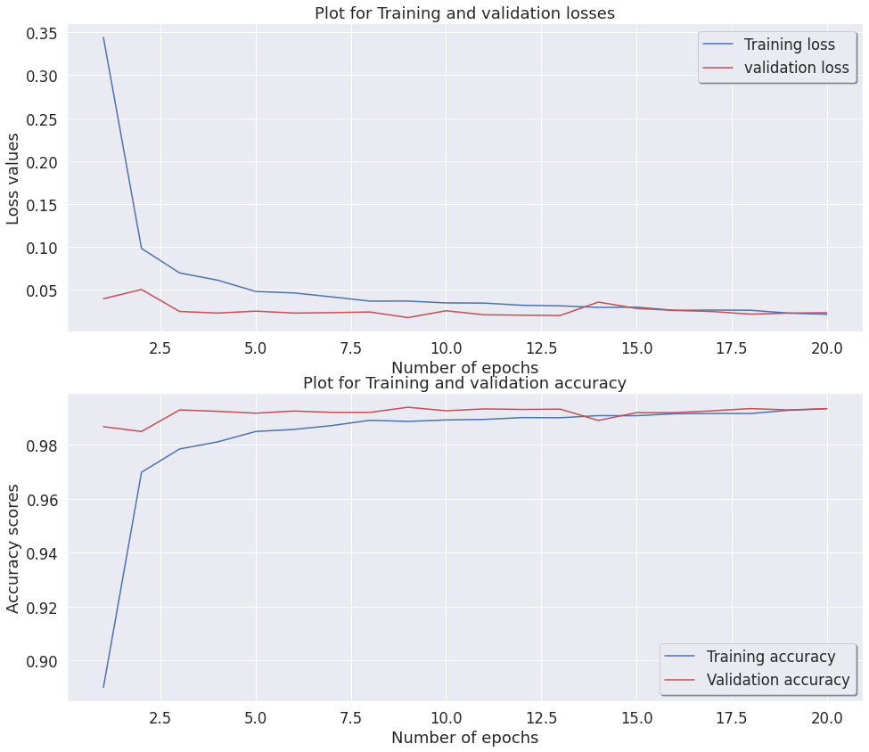

```python
# Plot the loss and accuracy curves for training and validation
fig, ax = plt.subplots(2,1, figsize=(16, 14))                                               # Setting the subplots and size
ax[0].plot(lepochs, history.history['loss'], color='b', label="Training loss")              # Plotting the Train loss
ax[0].plot(lepochs, history.history['val_loss'], color='r', label="validation loss")        # Plotting the test loss
ax[0].set_title("Plot for Training and validation losses")                                  # Set title
ax[0].set_ylabel('Loss values')                                                             # Set x label
ax[0].set_xlabel('Number of epochs')                                                        # Set y label
legend = ax[0].legend(loc='best', shadow=True)                                              # Place the legend at the best position when the graph is plotted

ax[1].plot(lepochs, history.history['accuracy'], color='b', label="Training accuracy")      # Plotting the Train accuracy
ax[1].plot(lepochs, history.history['val_accuracy'], color='r',label="Validation accuracy") # Plotting the Test accuracy
ax[1].set_title("Plot for Training and validation accuracy")                                # Set title
ax[1].set_ylabel('Accuracy scores')                                                         # Set x label
ax[1].set_xlabel('Number of epochs')                                                        # Set y label
legend = ax[1].legend(loc='best', shadow=True)                                              # Place the legend at the best position when the graph is plotted
plt.show()
```

### CNN: AlexNet tuning hyperparameter with random search.

Then, add in the data augmentation later to the model that had the best params. Then, include a early stopping

```python
# Creates a model given an activation and learning rate
def create_model(learning_rate, activation):

  opt = keras.optimizers.Adam(lr = learning_rate)                                                                                       # Create an Adam optimizer with the given learning rate

  AlexDARmodel = Sequential()                                                                                      # create model
  AlexDARmodel.add(Conv2D(filters=32, kernel_size=(3, 3), strides=(1, 1), padding='valid', activation='relu'))     # 1st Convolutional Layer
  AlexDARmodel.add(MaxPooling2D(pool_size=(3, 3), strides=(1, 1), padding='valid'))                                # Max Pooling
  AlexDARmodel.add(Conv2D(filters=32, kernel_size=(3, 3), strides=(1, 1), padding='valid', activation='relu'))     # 2nd Convolutional Layer
  AlexDARmodel.add(MaxPooling2D(pool_size=(3, 3), strides=(1, 1), padding='valid'))                                # Max Pooling
  AlexDARmodel.add(Conv2D(filters=64, kernel_size=(3, 3), strides=(1, 1), padding='valid', activation='relu'))     # 3rd Convolutional Layer
  AlexDARmodel.add(Conv2D(filters=64, kernel_size=(3, 3), strides=(1, 1), padding='valid', activation='relu'))     # 4th Convolutional Layer
  AlexDARmodel.add(MaxPooling2D(pool_size=(3, 3), strides=(2, 2), padding='valid'))                                # Max Pooling
  AlexDARmodel.add(Flatten())                                                                                      # Fully Connected layer
  AlexDARmodel.add(Dense(512, activation='relu'))                                                                  # 1st Fully Connected Layer
  AlexDARmodel.add(Dense(10, activation='softmax'))                                                                # Output Layer: 10 classes so 10 neurons

  # Compile your model with your optimizer, loss, and metrics
  AlexDARmodel.compile(optimizer = opt, loss = 'categorical_crossentropy', metrics = ['accuracy'])
  return AlexDARmodel


# Create a KerasClassifier
AlexDARmodel = KerasClassifier(build_fn = create_model)

# Define the parameters to try out
params = {'activation': ['relu', 'tahn'], 'batch_size': [150, 200, 250], 'epochs': [20, 30], 'learning_rate': [0.1, 0.01]}

# Create a randomize search cv object passing in the parameters to try
random_search = RandomizedSearchCV(AlexDARmodel, param_distributions = params, cv = 3)

# Get time
start_time = time.time()

# Running random_search.fit(X,y) would start the search,but it takes too long!
rand = random_search.fit(X_train, y_train)
```

```python
# Print results
print("Best: %f using %s" % (rand.best_score_, rand.best_params_))
randParam = rand.best_params_
```

```
Best: 0.980483 using {'learning_rate': 0.01, 'epochs': 20, 'batch_size': 250, 'activation': 'tahn'}
```

```python
# Data Augmenting: prevent overfitting
datagen = ImageDataGenerator(
        featurewise_center=False,             # set input mean to 0 over the dataset
        samplewise_center=False,              # set each sample mean to 0
        featurewise_std_normalization=False,  # divide inputs by std of the dataset
        samplewise_std_normalization=False,   # divide each input by its std
        zca_whitening=False,                  # apply ZCA whitening
        rotation_range=10,                    # randomly rotate images in the range (degrees, 0 to 180)
        zoom_range = 0.1,                     # Randomly zoom image
        width_shift_range=0.1,                # randomly shift images horizontally (fraction of total width)
        height_shift_range=0.1,               # randomly shift images vertically (fraction of total height)
        horizontal_flip=False,                # randomly flip images
        vertical_flip=False)                  # randomly flip images

datagen.fit(X_train)

# Bring in the callbacks
early_stop = EarlyStopping(monitor='val_loss', min_delta=0, patience=10, mode='auto')


AlexDARmodel = Sequential()                                                                                   # create model
AlexDARmodel.add(Conv2D(filters=32, kernel_size=(3, 3), strides=(1, 1), padding='valid', activation='relu'))  # 1st Convolutional Layer
AlexDARmodel.add(MaxPooling2D(pool_size=(3, 3), strides=(1, 1), padding='valid'))                             # Max Pooling
AlexDARmodel.add(Conv2D(filters=32, kernel_size=(3, 3), strides=(1, 1), padding='valid', activation='relu'))  # 2nd Convolutional Layer
AlexDARmodel.add(MaxPooling2D(pool_size=(3, 3), strides=(1, 1), padding='valid'))                             # Max Pooling
AlexDARmodel.add(Conv2D(filters=64, kernel_size=(3, 3), strides=(1, 1), padding='valid', activation='relu'))  # 3rd Convolutional Layer
AlexDARmodel.add(Conv2D(filters=64, kernel_size=(3, 3), strides=(1, 1), padding='valid', activation='relu'))  # 4th Convolutional Layer
AlexDARmodel.add(MaxPooling2D(pool_size=(3, 3), strides=(2, 2), padding='valid'))                             # Max Pooling
AlexDARmodel.add(Flatten())                                                                                   # Fully Connected layer
AlexDARmodel.add(Dense(512, activation='relu'))                                                               # 1st Fully Connected Layer
AlexDARmodel.add(Dense(10, activation='softmax'))                                                             # Output Layer: 10 classes so 10 neurons


# set learning rate from the best params
opt = keras.optimizers.Adam(learning_rate=randParam.get('learning_rate'))

# Compile model
AlexDARmodel.compile(loss='categorical_crossentropy', optimizer='adam', metrics=['accuracy'])

epochs = randParam.get('epochs')

# Fit the model
history = AlexDARmodel.fit(datagen.flow(X_train, y_train, batch_size = randParam.get('batch_size')), validation_data=(X_test, y_test), epochs = epochs, verbose=1, callbacks=early_stop)

# print the model summary
AlexDARmodel.summary()


# Final evaluation of the model: To get the percentage of the error
AANtrains = AlexDARmodel.evaluate(X_train, y_train, verbose=0)               # Scores for train set
AANtests = AlexDARmodel.evaluate(X_test, y_test, verbose=0)                  # Scores for test set
AANtrainl = 1-AANtrains[-1]                                                  # Loss for train set
AANtestl = 1-AANtests[-1]                                                    # Loss for test set

print("------------- %s seconds -------------" % (time.time() - start_time))  # Get the run time
print("Training accuracy: %.2f%%" % (AANtrains[-1]*100))
print("Baseline Error for train set: %.2f%%" % (AANtrainl*100))
print("Test Accuracy: %.2f%%" % (AANtests[-1]*100))
print("Baseline Error for test set: %.2f%%" % (AANtestl*100))
```

```
Model: "sequential_69"
_________________________________________________________________
Layer (type)                 Output Shape              Param #
=================================================================
conv2d_202 (Conv2D)          (None, None, None, 32)    320
_________________________________________________________________
max_pooling2d_101 (MaxPoolin (None, None, None, 32)    0
_________________________________________________________________
conv2d_203 (Conv2D)          (None, None, None, 32)    9248
_________________________________________________________________
max_pooling2d_102 (MaxPoolin (None, None, None, 32)    0
_________________________________________________________________
conv2d_204 (Conv2D)          (None, None, None, 64)    18496
_________________________________________________________________
conv2d_205 (Conv2D)          (None, None, None, 64)    36928
_________________________________________________________________
max_pooling2d_103 (MaxPoolin (None, None, None, 64)    0
_________________________________________________________________
flatten_68 (Flatten)         (None, None)              0
_________________________________________________________________
dense_173 (Dense)            (None, 512)               1606144
_________________________________________________________________
dense_174 (Dense)            (None, 10)                5130
=================================================================
Total params: 1,676,266
Trainable params: 1,676,266
Non-trainable params: 0
_________________________________________________________________
------------- 2540.7177214622498 seconds -------------
Training accuracy: 99.63%
Baseline Error for train set: 0.37%
Test Accuracy: 99.31%
Baseline Error for test set: 0.69%
```

```python
# Get the y, number of epochs
lepochs = [e+1 for e in range(len(history.history['loss']))]
lepochs
```

```
[1, 2, 3, 4, 5, 6, 7, 8, 9, 10, 11, 12, 13, 14, 15, 16, 17, 18, 19, 20]
```

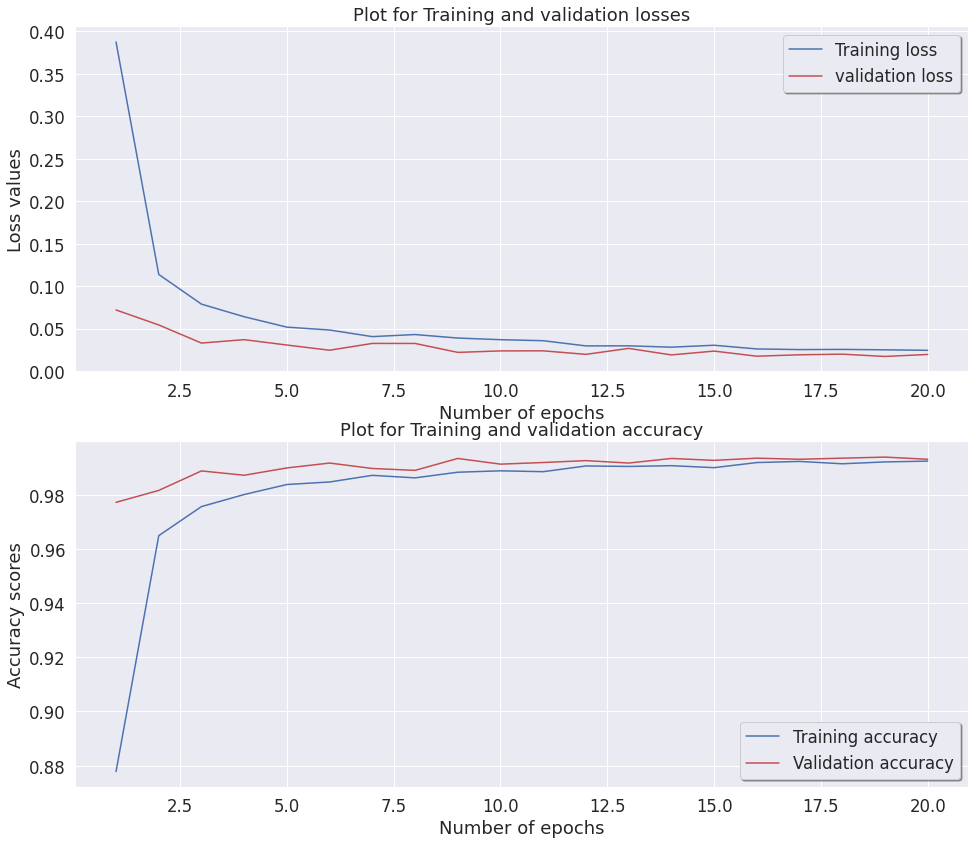

```python
# Plot the loss and accuracy curves for training and validation
fig, ax = plt.subplots(2,1, figsize=(16, 14))                                               # Setting the subplots and size
ax[0].plot(lepochs, history.history['loss'], color='b', label="Training loss")              # Plotting the Train loss
ax[0].plot(lepochs, history.history['val_loss'], color='r', label="validation loss")        # Plotting the test loss
ax[0].set_title("Plot for Training and validation losses")                                  # Set title
ax[0].set_ylabel('Loss values')                                                             # Set x label
ax[0].set_xlabel('Number of epochs')                                                        # Set y label
legend = ax[0].legend(loc='best', shadow=True)                                              # Place the legend at the best position when the graph is plotted

ax[1].plot(lepochs, history.history['accuracy'], color='b', label="Training accuracy")      # Plotting the Train accuracy
ax[1].plot(lepochs, history.history['val_accuracy'], color='r',label="Validation accuracy") # Plotting the Test accuracy
ax[1].set_title("Plot for Training and validation accuracy")                                # Set title
ax[1].set_ylabel('Accuracy scores')                                                         # Set x label
ax[1].set_xlabel('Number of epochs')                                                        # Set y label
legend = ax[1].legend(loc='best', shadow=True)                                              # Place the legend at the best position when the graph is plotted
plt.show()
```

### CNN: AlexNet confusion matrix for the fine tuned AlexNet

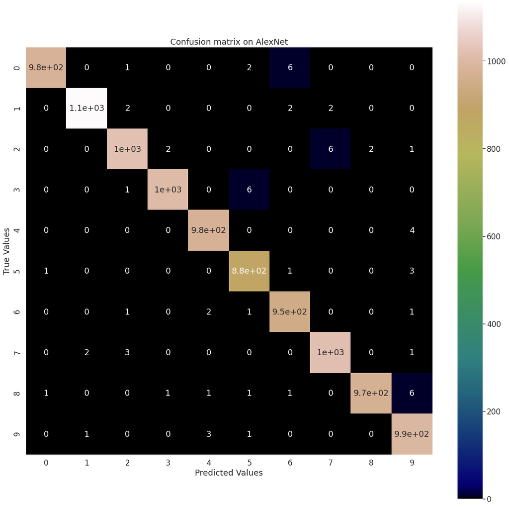

```python
plt.figure(figsize=(20, 20))                         # Set Figure
sns.set(font_scale=1.5)                              # Set the font size

Ay_pred = AlexDARmodel.predict(X_test)               # Predict encoded label as 2 => [0, 0, 1, 0, 0, 0, 0, 0, 0, 0]

Ay_pred = np.argmax(Ay_pred, 1)                      # Decode Predicted labels
y_test = np.argmax(y_test, 1)                        # Decode labels

matrix = confusion_matrix(y_test, Ay_pred)           # Confusion matrix of correct labels against predicted labels

# Plot Confusion matrix
sns.heatmap(matrix.T, square=True, annot=True, cmap='gist_earth').set_title("Confusion matrix on AlexNet")
plt.xlabel('Predicted Values')
plt.ylabel('True Values')
plt.show()
```

# Compare the accuracy scores as well as the baseline erorrs

```python
# Based on accruacy scores
results = pd.DataFrame({
    # The model names
    'Model': ['LeNet-5', 'AlexNet'],


    # The accuracy scores of train set (Default)
    'Train Score (Default)': [(LNtrains[-1]*100), (ANtrains[-1]*100)],

    # The accuracy scores of test set (Default)
    'Test Score (Default)': [(LNtests[-1]*100), (ANtests[-1]*100)],

    # The difference in accuracy scores between test and train set (Default)
    'Score Difference (Default)': [((LNtrains[-1]*100)-(LNtests[-1]*100)), ((ANtrains[-1]*100)-(ANtests[-1]*100))],


    # The accuracy scores of train set (Default + Data Augmentation)
    'Train Score (Default + Data Augmentation)': [(DLNtrains[-1]*100), (DANtrains[-1]*100)],

    # The accuracy scores of test set (Default + Data Augmentation)
    'Test Score (Default + Data Augmentation)': [(DLNtests[-1]*100), (DANtests[-1]*100)],

    # The difference in accuracy scores between test and train set (Default + Data Augmentation)
    'Score Difference (Default + Data Augmentation)': [((DLNtrains[-1]*100)-(DLNtests[-1]*100)), ((DANtrains[-1]*100)-(DANtests[-1]*100))],


    # The accuracy scores of train set (RandomSearchCV + Data Augmentation)
    'Train Score (RandomSearchCV + Data Augmentation)': [(ALNtrains[-1]*100), (AANtrains[-1]*100)],

    # The accuracy scores of test set (RandomSearchCV + Data Augmentation)
    'Test Score (RandomSearchCV + Data Augmentation)': [(ALNtests[-1]*100), (AANtests[-1]*100)],

    # The difference in accuracy scores between test and train set (RandomSearchCV + Data Augmentation)
    'Score Difference (RandomSearchCV + Data Augmentation)': [((ALNtrains[-1]*100)-(ALNtests[-1]*100)), ((AANtrains[-1]*100)-(AANtests[-1]*100))]})

# Make a dataframe and parse in values
res = results.sort_values(by='Model', ascending=False)
# Sort by difference and rest index: reset the index without inserting it as a column
res = res.set_index('Model')
res
```

| Model | Train Score (Default) | Test Score (Default) | Score Difference (Default) | Train Score (Default + Data Augmentation) | Test Score (Default + Data Augmentation) | Score Difference (Default + Data Augmentation) | Train Score (RandomSearchCV + Data Augmentation) | Test Score (RandomSearchCV + Data Augmentation) | Score Difference (RandomSearchCV + Data Augmentation) |
| --- | --- | --- | --- | --- | --- | --- | --- | --- | --- |
| LeNet-5 | 99.736667 | 99.019998 | 0.716668 | 99.269998 | 99.180001 | 0.089997 | 98.983335 | 98.830003 | 0.153333 |
| AlexNet | 99.846667 | 99.159998 | 0.686669 | 99.599999 | 99.349999 | 0.250000 | 99.628335 | 99.309999 | 0.318336 |

```python
# Based on losses
results = pd.DataFrame({
    # The model names
    'Model': ['LeNet-5', 'AlexNet'],


    # The losses of train set (Default)
    'Train Loss (Default)': [(LNtrainl*100), (ANtrainl*100)],

    # The losses of test set (Default)
    'Test Loss (Default)': [(LNtestl*100), (ANtestl*100)],


    # The losses of train set (Default + Data Augmentation)
    'Train Loss (Default + Data Augmentation)': [(DLNtrainl*100), (DANtrainl*100)],

    # The losses of test set (Default + Data Augmentation)
    'Test Loss (Default + Data Augmentation)': [(DLNtestl*100), (DANtestl*100)],


    # The losses of train set (RandomSearchCV + Data Augmentation)
    'Train Loss (RandomSearchCV + Data Augmentation)': [(ALNtrainl*100), (AANtrainl*100)],

    # The losses of test set (RandomSearchCV + Data Augmentation)
    'Test Loss (RandomSearchCV + Data Augmentation)': [(ALNtestl*100), (AANtestl*100)]})

# Make a dataframe and parse in values
res = results.sort_values(by='Model', ascending=False)
# Sort by difference and rest index: reset the index without inserting it as a column
res = res.set_index('Model')
res
```

| Model | Train Loss (Default) | Test Loss (Default) | Train Loss (Default + Data Augmentation) | Test Loss (Default + Data Augmentation) | Train Loss (RandomSearchCV + Data Augmentation) | Test Loss (RandomSearchCV + Data Augmentation) |
| --- | --- | --- | --- | --- | --- | --- |
| LeNet-5 | 0.263333 | 0.980002 | 0.730002 | 0.819999 | 1.016665 | 1.169997 |
| AlexNet | 0.153333 | 0.840002 | 0.400001 | 0.650001 | 0.371665 | 0.690001 |

```
Loaded successfully.
```

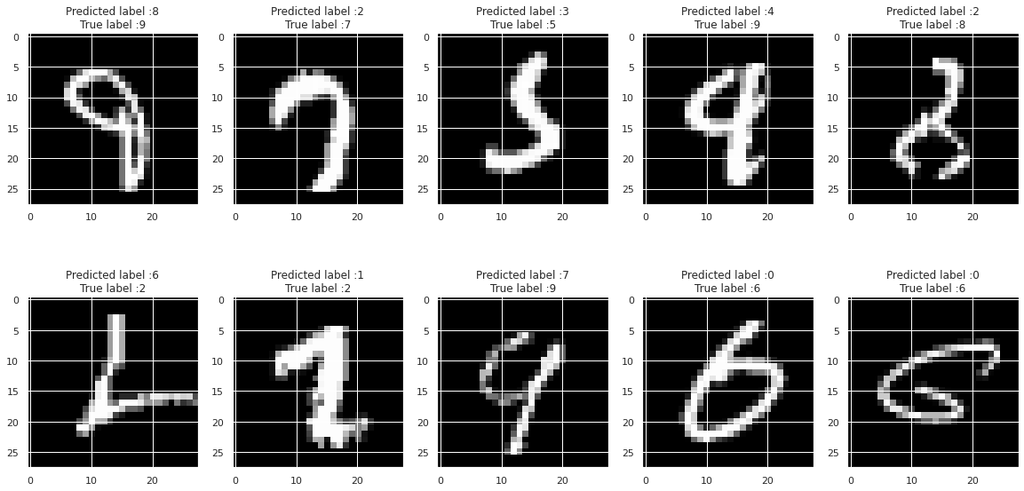

```python
# From here, the best model is: AlexNet
Ay_wrong =  []

for i in range(len(Ay_pred)):
  if Ay_pred[i] != y_test[i]:
    Ay_wrong.append(i)


# load (downloaded if needed) the MNIST dataset
# The shape of X being parsed into the model is different from the shape of X just loaded
# Just... load the data and use it instead
(X_train, y_train), (X_test, y_test) = mnist.load_data()

# Successfully loaded note
print("Loaded successfully.")

sns.set(font_scale=1)

fig, axis = plt.subplots(2, 5, figsize=(20, 10))
for i, ax in enumerate(axis.flat): # Print each images
    ax.imshow(X_test[Ay_wrong[i]], cmap='gray') # This shows the picture
    ax.set(title = "Predicted label :{}\nTrue label :{}".format(Ay_pred[Ay_wrong[i]], y_test[Ay_wrong[i]]))

# show the plot
plt.show()
```

# How is your prediction task defined? And what is the meaning of the output variable?

In this prediction task, we are using CNN architecture to classify the digit MNIST dataset. And the output variable would be how accurate the models correctly classify the digits.

# How is the data represented as features?

The features would be the labels, data in y.  
X_train and X_test would be parsed in the same, but in 4-dim (number of samples, length, width, canal)  
y_train and y_test would be parsed in with encoded labels to one hot vectors.

# Did you process the features in any way (e.g. normalization)?

- ### Normalization helps to reduce the effect of illumination's differences. CNN converge faster on 0-1 data than on 0-255.
- ### Encode labels to one hot vectors (e.g. 2 = [0,0,1,0,0,0,0,0,0,0])
- ### Reshaping of data depends on the model used or different implementation of tools
  - LeNet-5, AlexNet and Data Augmentation: Reshaping the data to 4 dimension.
  - In order to parse in data in the ImageDataGenerator() function, 4 dimension data is needed. Just need to reshape the data will do.

# How did you select which CNN architecture to use?

1. See if the learning models are suitable for the problem (CNN architecture)
2. Compare them with their default state and choose the best evaluation score for testing set
3. Then, the difference in evaluation score when testing against train set (closest to 0)
4. After choosing the 'best model', Fine tune hyperparameters and compare it with its former result
5. Will just go with LeNet-5 and AlexNet as they both are the most commonly used models for digit recognition.
- LeNet-5
- AlexNet

# How do you evaluate the quality of your system?

Compare the models' (Default)  
Then, the same with models with Default + data augmentation  
Then, the same with models with data augmentation + tuning of hyperparameters

- Accuracy scores
- CNN error
- Overfitting rate

# Can you say anything about the errors that the system makes? You may consider a confusion matrix.

For LeNet-5:

- Majority of the digits are classified correctly.
- However there are some digits were classified wrongly. LeNet-5 misclassify '7' as '9' as well as '4' as '9' the most as 7 of them were misclassified.
- Probably, the structures of '7' and '9' are similar. Direction of the writing is pointing downwards, top part of '7' might be curved which could cause '7' to look like '9' which makes the model to misclassify them.
- Likewise for '4' and '9'. Both have holes at the top part and some people might write a more cursive '4' which could look like '9'

# Please show how you have improved the model from the initial performance, e.g. by hyperparameter turning, by modifying the network architecture, or by introducing regularization using Dropout, etc.

#### Initial performance for each model. Then do the same for just data augmentation to see the difference. Then, tuning parameter or adding deep and narrower network on the attempt with data augmentation. Compare and show the improvement based on losses and accuracy.

- **Tune Parameters**
  1. Changing epoch values, learning rate
  2. Adding in dropout function, adding optimiser.
- **Image Data Augmentation**
  1. Using ImageDataGenerator
  2. Image shifts via the width_shift_range and height_shift_range arguments.
  3. Image flips via the horizontal_flip and vertical_flip arguments.
  4. Image rotations via the rotation_range argument
  5. Image brightness via the brightness_range argument.
  6. Image zoom via the zoom_range argument.
  7. Add a False to random shifts as to prevent the model to mistake '6' and '9'
- **Dealing with underfitting and overfitting**
  1. Underfitting: Add more layers and might need to tune the parameters
  2. Overfitting: Using data augmentation to increase the size of the data which large training data might avoid the overfitting issue. Also used an early stopping function to stop the training process before generalization ability to go weaker. Added a cross-validation function to reduce the overfitting problem further.

# Provide a reference section for any papers, online articles, books, publications that you may have referenced.

Yann L, Corinna C and Christopher J.C. B. Available from: http://yann.lecun.com/exdb/mnist/ [Accessed 20 October 2020]

Orhan G. 2018. Image Classification in 10 Minutes with MNIST Dataset [online] Poole: towards data science. Available from: https://towardsdatascience.com/image-classification-in-10-minutes-with-mnist-dataset-54c35b77a38d [Accessed 29 October 2020]  
Raimi K. 2020. Illustrated: 10 CNN Architectures [online] Poole: github.io Available from: https://towardsdatascience.com/illustrated-10-cnn-architectures-95d78ace614d [Accessed 29 October 2020]  
Mr. Data Science, 2020. How To Import The MNIST Dataset Using Tensorflow [online] Poole: Mr. Data Science. Available from: https://medium.com/@mrdatascience/how-to-import-the-mnist-dataset-using-tensorflow-a972322991a6 [Accessed 29 October 2020]  
PyBear, 2020. [CNN] Transfer learning + Data augmentation ! [online] Poole: kaggle. Available from: https://www.kaggle.com/pybear/cnn-100-transfer-learning-data-augmentation [Accessed 6 November 2020]  
Team, 2019. MNIST: Simple CNN keras (Accuracy : 0.99)=>Top 1% [online] Poole: kaggle. Available from: https://www.kaggle.com/elcaiseri/mnist-simple-cnn-keras-accuracy-0-99-top-1#2.-Data-preparation [Accessed 6 November 2020]  
Yassine G, 2017. Introduction to CNN Keras - 0.997 (top 6%) [online] Poole: Kaggle. Available from: https://www.kaggle.com/yassineghouzam/introduction-to-cnn-keras-0-997-top-6#Introduction-to-CNN-Keras---Acc-0.997-(top-8%) [Accessed 7 November 2020]  
Jason B, 2018. A Gentle Introduction to Probability Scoring Methods in Python [online] Poole: Machine Learning Mastery. Available from: https://machinelearningmastery.com/how-to-score-probability-predictions-in-python/ [Accessed 7 November 2020]  
Christ. D, 2018. How to choose CNN Architecture MNIST [online] Poole: Kaggle. Available from: https://www.kaggle.com/cdeotte/how-to-choose-cnn-architecture-mnist [Accessed 9 November 2020]  
Ishan. S, 2018. Digit Recognizer - MNIST Dataset [online] Poole: Kaggle. Available from: https://www.kaggle.com/ishansoni/digit-recognizer-mnist-dataset [Accessed 9 November 2020]  
Jędrzej. D, 2020. MNIST dataset -100% Top 10% [online] Poole: Kaggle. Available from: https://www.kaggle.com/jedrzejdudzicz/mnist-dataset-100-top-6 [Accessed 11 November 2020]  
Emna. A, 2020. 4 CNN Networks Every Machine Learning Engineer Should Know [online] Poole: TopBots. Available from: https://www.topbots.com/important-cnn-architectures/#:~:text=release%20new%20material.-,LeNet%2D5,is%20the%20LeNet%2D5%20architecture. [Accessed 11 November 2020]  
Jerry W, 2019. AlexNet: The Architecture that Challenged CNNs [online] Poole: towards data science. Available from: https://towardsdatascience.com/alexnet-the-architecture-that-challenged-cnns-e406d5297951#:~:text=AlexNet%20allows%20for%20multi%2DGPU,Overlapping%20Pooling. [Accessed 12 November 2020]  
Aqeel A, 2019. Difference between AlexNet, VGGNet, ResNet, and Inception [online] Poole: towards data science. Available from: https://towardsdatascience.com/the-w3h-of-alexnet-vggnet-resnet-and-inception-7baaaecccc96 [Accessed 12 November 2020]  
Khush P, 2020. Architecture comparison of AlexNet, VGGNet, ResNet, Inception, DenseNet [online] Poole: towards data science. Available from: https://towardsdatascience.com/architecture-comparison-of-alexnet-vggnet-resnet-inception-densenet-beb8b116866d [Accessed 12 November 2020]

Dipti P, 2018. Improving Performance of Convolutional Neural Network! [online] Poole: medium. Available from: https://medium.com/@dipti.rohan.pawar/improving-performance-of-convolutional-neural-network-2ecfe0207de7 [Accessed 14 November 2020]

Soumik R, 2018. Digit Recognition Using Lenet - 5 [online] Poole: kaggle. Available from: https://www.kaggle.com/soumikrakshit/digit-recognition-using-lenet-5 [Assessed 15 November 2020]

Jason B, 2016. How to Grid Search Hyperparameters for Deep Learning Models in Python With Keras [online] Poole: Machine Learning Mastery. https://machinelearningmastery.com/grid-search-hyperparameters-deep-learning-models-python-keras/ [Assessed 16 November 2020]

Raúl G, 2018. Understanding Categorical Cross-Entropy Loss, Binary Cross-Entropy Loss, Softmax Loss, Logistic Loss, Focal Loss and all those confusing names [online] Poole: Github. https://gombru.github.io/2018/05/23/cross_entropy_loss/ [Assessed 18 November 2020]

Michael X, 2019. Neural Networks - 4. Convolutional Neural Networks: Example with Keras [online] Poole: Github. http://www.michaelfxu.com/neural%20networks%20series/neural-networks-pt4-cnn-codes/ [Assessed 19 November 2020]